# Project

Bob Ding, Lynn Fan, Alice Jiang

11/18/2018

# Data Exploration

```r
# input data source
data <- read.csv("./redwine_quality.csv")
```

```r
# convert quality into factor variable
data <- data %>% mutate(quality = as.factor(quality))
```

```r
# overview of the dataset
kable(tidy(summary(data)))
```

| Var1 | Var2 | n |
| --- | --- | --- |
|  | fixed.acidity | Min. : 4.60 |
|  | fixed.acidity | 1st Qu.: 7.10 |
|  | fixed.acidity | Median : 7.90 |
|  | fixed.acidity | Mean : 8.32 |
|  | fixed.acidity | 3rd Qu.: 9.20 |
|  | fixed.acidity | Max. :15.90 |
|  | volatile.acidity | Min. :0.1200 |
|  | volatile.acidity | 1st Qu.:0.3900 |
|  | volatile.acidity | Median :0.5200 |
|  | volatile.acidity | Mean :0.5278 |
|  | volatile.acidity | 3rd Qu.:0.6400 |
|  | volatile.acidity | Max. :1.5800 |
|  | citric.acid | Min. :0.000 |
|  | citric.acid | 1st Qu.:0.090 |
|  | citric.acid | Median :0.260 |
|  | citric.acid | Mean :0.271 |
|  | citric.acid | 3rd Qu.:0.420 |
|  | citric.acid | Max. :1.000 |
|  | residual.sugar | Min. : 0.900 |
|  | residual.sugar | 1st Qu.: 1.900 |
|  | residual.sugar | Median : 2.200 |
|  | residual.sugar | Mean : 2.539 |
|  | residual.sugar | 3rd Qu.: 2.600 |
|  | residual.sugar | Max. :15.500 |
|  | chlorides | Min. :0.01200 |
|  | chlorides | 1st Qu.:0.07000 |
|  | chlorides | Median :0.07900 |
|  | chlorides | Mean :0.08747 |
|  | chlorides | 3rd Qu.:0.09000 |
|  | chlorides | Max. :0.61100 |
|  | free.sulfur.dioxide | Min. : 1.00 |
|  | free.sulfur.dioxide | 1st Qu.: 7.00 |
|  | free.sulfur.dioxide | Median :14.00 |
|  | free.sulfur.dioxide | Mean :15.87 |
|  | free.sulfur.dioxide | 3rd Qu.:21.00 |
|  | free.sulfur.dioxide | Max. :72.00 |
|  | total.sulfur.dioxide | Min. : 6.00 |
|  | total.sulfur.dioxide | 1st Qu.: 22.00 |
|  | total.sulfur.dioxide | Median : 38.00 |
|  | total.sulfur.dioxide | Mean : 46.47 |
|  | total.sulfur.dioxide | 3rd Qu.: 62.00 |
|  | total.sulfur.dioxide | Max. :289.00 |
|  | density | Min. :0.9901 |
|  | density | 1st Qu.:0.9956 |
|  | density | Median :0.9968 |
|  | density | Mean :0.9967 |
|  | density | 3rd Qu.:0.9978 |
|  | density | Max. :1.0037 |
|  | pH | Min. :2.740 |
|  | pH | 1st Qu.:3.210 |
|  | pH | Median :3.310 |
|  | pH | Mean :3.311 |
|  | pH | 3rd Qu.:3.400 |
|  | pH | Max. :4.010 |
|  | sulphates | Min. :0.3300 |
|  | sulphates | 1st Qu.:0.5500 |
|  | sulphates | Median :0.6200 |
|  | sulphates | Mean :0.6581 |
|  | sulphates | 3rd Qu.:0.7300 |
|  | sulphates | Max. :2.0000 |
|  | alcohol | Min. : 8.40 |
|  | alcohol | 1st Qu.: 9.50 |
|  | alcohol | Median :10.20 |
|  | alcohol | Mean :10.42 |
|  | alcohol | 3rd Qu.:11.10 |
|  | alcohol | Max. :14.90 |
|  | quality | 3: 10 |
|  | quality | 4: 53 |
|  | quality | 5:681 |
|  | quality | 6:638 |
|  | quality | 7:199 |
|  | quality | 8: 18 |

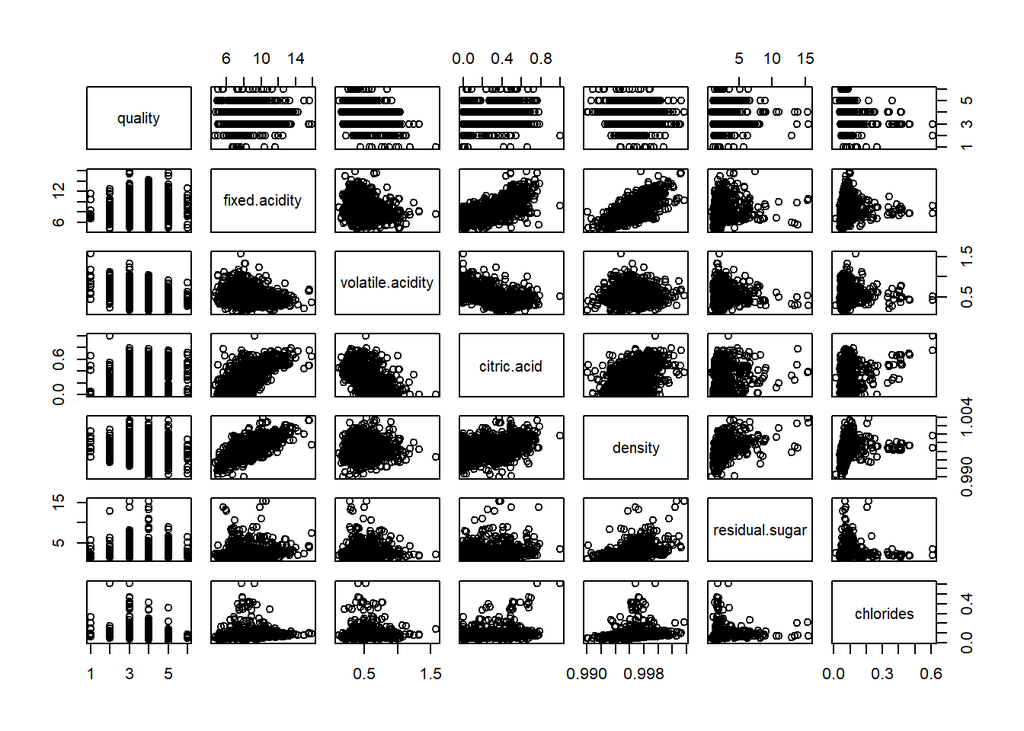

```r
# scatter plot matrix one
pairs(quality ~ fixed.acidity + volatile.acidity + citric.acid + density + residual.sugar + chlorides, data=data)
```

```r
# correlation coefficients for potential multicollinearity
cor(data$fixed.acidity, data$citric.acid)
```

```
## [1] 0.6717034
```

```r
cor(data$fixed.acidity, data$density)
```

```
## [1] 0.6680473
```

```r
cor(data$volatile.acidity, data$citric.acid)
```

```
## [1] -0.5524957
```

```r
cor(data$density, data$residual.sugar)
```

```
## [1] 0.3552834
```

The correlation coefficent for fixed.acidity and citric.acid (0.6717034) and the correlation coefficient for fixed.acidity and density (0.6680473) show moderate to strong linear relationship between the variables. To remove potential multicollinearity impact, we **will not include fixed.acidity** in the model.

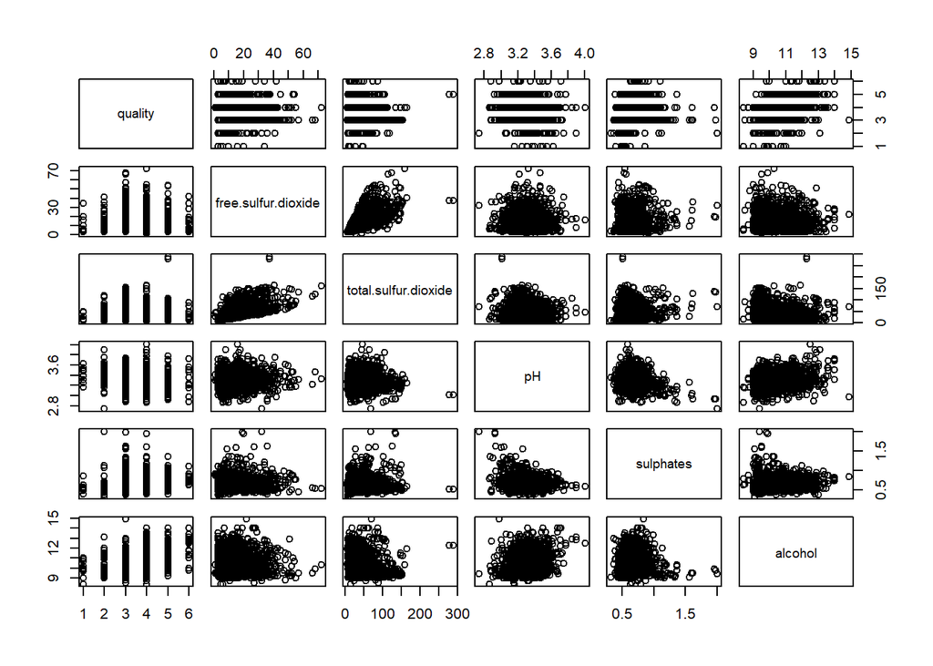

```r
# scatter plot matrix two
pairs(quality ~ free.sulfur.dioxide + total.sulfur.dioxide + pH + sulphates + alcohol, data=data)
```

The scatter plot shows strong positive linear relationship between free.sulfur.dioxide and total.sulfur.dioxide.

```r
# correlation coefficients for potential multicollinearity
cor(data$free.sulfur.dioxide, data$total.sulfur.dioxide)
```

```
## [1] 0.6676665
```

The correlation coefficient of 0.6676665 between free.sulfur.dioxide and total.sulfur.dioxide indicates strong positive linear relationship. We also know from the data description that total.sulfur dioxide includes free.sulfur.dioxide - whose concentration level could impact the smell and taste of the wine, thus impacting quality. So it is sufficient to include only one of these two variables in the model, and we **will include free.sulphur.dioxide**.

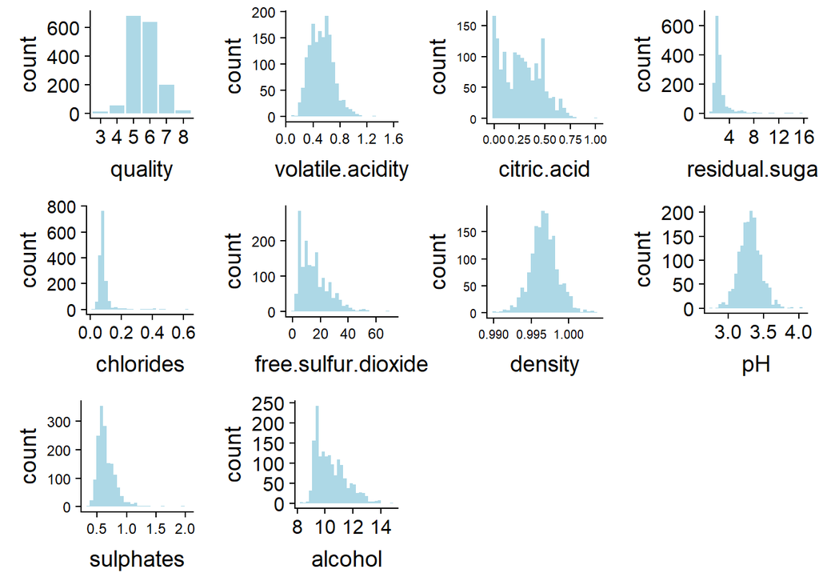

```r
# distribution of each variable
p1  <- ggplot(data = data, aes(x = quality) ) + geom_histogram(stat="count",fill= "lightblue")
p3  <- ggplot(data = data, aes(x = volatile.acidity) ) + theme(axis.text=element_text(size=9)) + geom_histogram(fill= "lightblue")
p4  <- ggplot(data = data, aes(x = citric.acid) ) + theme(axis.text=element_text(size=7)) + geom_histogram(fill= "lightblue")
p5  <- ggplot(data = data, aes(x = residual.sugar) ) + geom_histogram(fill= "lightblue")
p6  <- ggplot(data = data, aes(x = chlorides) ) + theme(axis.text=element_text(size=11)) + geom_histogram(fill= "lightblue")
p7  <- ggplot(data = data, aes(x = free.sulfur.dioxide) ) + theme(axis.text=element_text(size=9)) + geom_histogram(fill= "lightblue")
p9  <- ggplot(data = data, aes(x = density) ) + theme(axis.text=element_text(size=7.5)) + geom_histogram(fill= "lightblue")
p10 <- ggplot(data = data, aes(x = pH) ) + geom_histogram(fill= "lightblue")
p11 <- ggplot(data = data, aes(x = sulphates) ) + theme(axis.text=element_text(size=9)) + geom_histogram(fill= "lightblue")
p12 <- ggplot(data = data, aes(x = alcohol) ) + geom_histogram(fill= "lightblue")

plot_grid(p1,p3,p4,p5,p6,p7,p9,p10,p11,p12,ncol = 4,nrow = 3)
```

```r
# log transform the citric.aci, free.sulfure.dioxide, and alcohol
# data$citric.acid <- log(15*data$citric.acid+1)
data$free.sulfur.dioxide<- log(data$free.sulfur.dioxide)
data$alcohol <- log(data$alcohol)
```

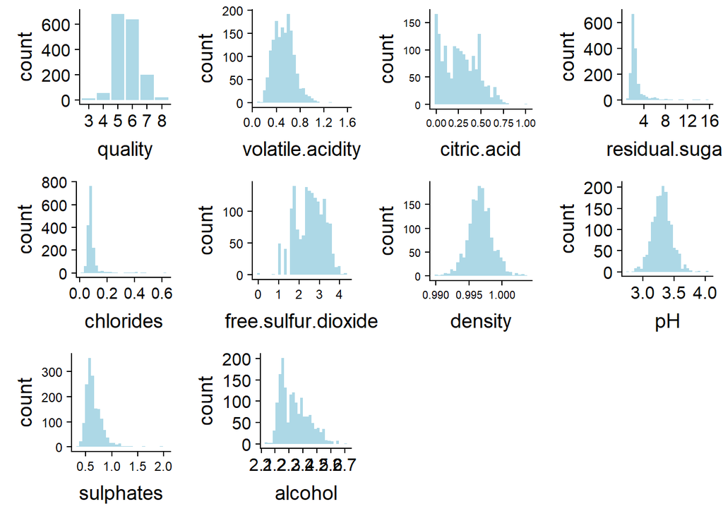

```r
# distribution of each variable
p1  <- ggplot(data = data, aes(x = quality) ) + geom_histogram(stat="count",fill= "lightblue")
p3  <- ggplot(data = data, aes(x = volatile.acidity) ) + theme(axis.text=element_text(size=9)) + geom_histogram(fill= "lightblue")
p4  <- ggplot(data = data, aes(x = citric.acid) ) + theme(axis.text=element_text(size=7)) + geom_histogram(fill= "lightblue")
p5  <- ggplot(data = data, aes(x = residual.sugar) ) + geom_histogram(fill= "lightblue")
p6  <- ggplot(data = data, aes(x = chlorides) ) + theme(axis.text=element_text(size=11)) + geom_histogram(fill= "lightblue")
p7  <- ggplot(data = data, aes(x = free.sulfur.dioxide) ) + theme(axis.text=element_text(size=9)) + geom_histogram(fill= "lightblue")
p9  <- ggplot(data = data, aes(x = density) ) + theme(axis.text=element_text(size=7.5)) + geom_histogram(fill= "lightblue")
p10 <- ggplot(data = data, aes(x = pH) ) + geom_histogram(fill= "lightblue")
p11 <- ggplot(data = data, aes(x = sulphates) ) + theme(axis.text=element_text(size=9)) + geom_histogram(fill= "lightblue")
p12 <- ggplot(data = data, aes(x = alcohol) ) + geom_histogram(fill= "lightblue")

plot_grid(p1,p3,p4,p5,p6,p7,p9,p10,p11,p12,ncol = 4,nrow = 3)
```

```r
# summary statistics of each variable
summary(data)
```

```
##  fixed.acidity   volatile.acidity  citric.acid    residual.sugar
##  Min.   : 4.60   Min.   :0.1200   Min.   :0.000   Min.   : 0.900
##  1st Qu.: 7.10   1st Qu.:0.3900   1st Qu.:0.090   1st Qu.: 1.900
##  Median : 7.90   Median :0.5200   Median :0.260   Median : 2.200
##  Mean   : 8.32   Mean   :0.5278   Mean   :0.271   Mean   : 2.539
##  3rd Qu.: 9.20   3rd Qu.:0.6400   3rd Qu.:0.420   3rd Qu.: 2.600
##  Max.   :15.90   Max.   :1.5800   Max.   :1.000   Max.   :15.500
##    chlorides       free.sulfur.dioxide total.sulfur.dioxide
##  Min.   :0.01200   Min.   :0.000       Min.   :  6.00
##  1st Qu.:0.07000   1st Qu.:1.946       1st Qu.: 22.00
##  Median :0.07900   Median :2.639       Median : 38.00
##  Mean   :0.08747   Mean   :2.546       Mean   : 46.47
##  3rd Qu.:0.09000   3rd Qu.:3.045       3rd Qu.: 62.00
##  Max.   :0.61100   Max.   :4.277       Max.   :289.00
##     density             pH          sulphates         alcohol      quality
##  Min.   :0.9901   Min.   :2.740   Min.   :0.3300   Min.   :2.128   3: 10
##  1st Qu.:0.9956   1st Qu.:3.210   1st Qu.:0.5500   1st Qu.:2.251   4: 53
##  Median :0.9968   Median :3.310   Median :0.6200   Median :2.322   5:681
##  Mean   :0.9967   Mean   :3.311   Mean   :0.6581   Mean   :2.339   6:638
##  3rd Qu.:0.9978   3rd Qu.:3.400   3rd Qu.:0.7300   3rd Qu.:2.407   7:199
##  Max.   :1.0037   Max.   :4.010   Max.   :2.0000   Max.   :2.701   8: 18
```

From the previous histogram, we can see that quality has a fairly normal distribution. The summary statistic also shows that quality rating of 5 has the most number of observations (it is also the middle rating on the scale of 0-10). So quality rating of 5 is the most appropriate **reference level** for the model.

```r
# makes quality==5 the reference level
data <- data %>% mutate(quality = relevel(quality, ref=5))
```

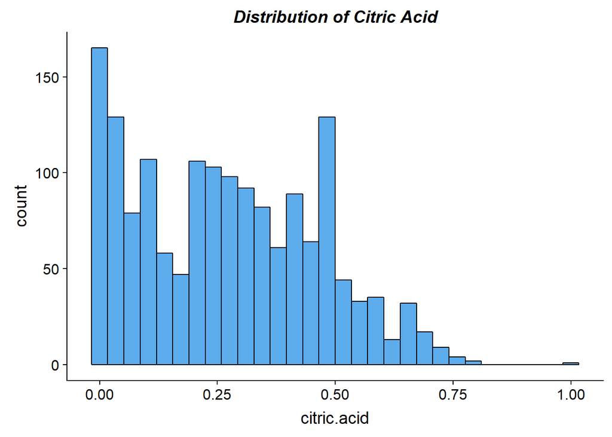

```r
# distribution of citric acid
ggplot(aes(x=citric.acid), data=data) +
  geom_histogram(fill="steelblue2", color="black") +
  ggtitle("Distribution of Citric Acid") +
  theme(plot.title=element_text(color="black", size=14, face="bold.italic", hjust=0.5))
```

```r
# add mean-centered numerical variables besides citric.acid
data <- data %>%
  mutate(volatile.acidityCent = volatile.acidity-mean(volatile.acidity),
         residual.sugarCent = residual.sugar-mean(residual.sugar),
         chloridesCent = chlorides-mean(chlorides),
         free.sulfur.dioxideCent = free.sulfur.dioxide-mean(free.sulfur.dioxide),
         sulphatesCent = sulphates-mean(sulphates),
         densityCent = density-mean(density), pHCent = pH-mean(pH),
         alcoholCent = alcohol-mean(alcohol))
```

# Multiple Regression Analysis

```r
# change quality into a numerical variable
data <- data %>% mutate(quality = as.numeric(quality))
```

```r
# primary model
full.model <- lm(quality ~ volatile.acidityCent + residual.sugarCent + citric.acid + chloridesCent + free.sulfur.dioxideCent + sulphatesCent + densityCent + pHCent + alcoholCent, data=data)
```

```r
# view the primary model
kable(tidy(full.model), format="markdown")
```

| term | estimate | std.error | statistic | p.value |
| --- | --- | --- | --- | --- |
| (Intercept) | 4.2100469 | 0.0768942 | 54.7511415 | 0.0000000 |
| volatile.acidityCent | -0.1465602 | 0.2264199 | -0.6472938 | 0.5175353 |
| residual.sugarCent | -0.0636735 | 0.0251102 | -2.5357595 | 0.0113155 |
| citric.acid | -0.7659187 | 0.2596304 | -2.9500346 | 0.0032239 |
| chloridesCent | 1.4314094 | 0.7790328 | 1.8374187 | 0.0663347 |
| free.sulfur.dioxideCent | 0.1204940 | 0.0469359 | 2.5672001 | 0.0103432 |
| sulphatesCent | -0.5767364 | 0.2162817 | -2.6665979 | 0.0077401 |
| densityCent | 54.4991734 | 25.0277971 | 2.1775458 | 0.0295866 |
| pHCent | 0.0818268 | 0.2552561 | 0.3205674 | 0.7485804 |
| alcoholCent | -1.4930492 | 0.4407494 | -3.3875241 | 0.0007225 |

```r
# check model fit
glance(full.model)
```

```
## # A tibble: 1 x 11
##   r.squared adj.r.squared sigma statistic  p.value    df logLik   AIC   BIC
## *     <dbl>         <dbl> <dbl>     <dbl>    <dbl> <int>  <dbl> <dbl> <dbl>
## 1    0.0566        0.0513  1.24      10.6 4.36e-16    10 -2609. 5240. 5299.
## # ... with 2 more variables: deviance <dbl>, df.residual <int>
```

We will then use model selection to build a better model, first including only the main effects.

## Model Selections

```r
# backward selection process
backward <- ols_step_backward_aic(full.model, details=TRUE)
```

```
## Backward Elimination Method
## ---------------------------
##
## Candidate Terms:
##
## 1 . volatile.acidityCent
## 2 . residual.sugarCent
## 3 . citric.acid
## 4 . chloridesCent
## 5 . free.sulfur.dioxideCent
## 6 . sulphatesCent
## 7 . densityCent
## 8 . pHCent
## 9 . alcoholCent
##
##  Step 0: AIC = 5240.161
##  quality ~ volatile.acidityCent + residual.sugarCent + citric.acid + chloridesCent + free.sulfur.dioxideCent + sulphatesCent + densityCent + pHCent + alcoholCent
##
## -------------------------------------------------------------------------------------
## Variable                   DF      AIC       Sum Sq      RSS       R-Sq     Adj. R-Sq
## -------------------------------------------------------------------------------------
## pHCent                     1     5238.264     0.158    2447.229    0.057        0.052
## volatile.acidityCent       1     5238.583     0.645    2447.716    0.056        0.052
## chloridesCent              1     5241.555     5.199    2452.270    0.055        0.050
## densityCent                1     5242.925     7.302    2454.373    0.054        0.049
## residual.sugarCent         1     5244.618     9.902    2456.973    0.053        0.048
## free.sulfur.dioxideCent    1     5244.779    10.149    2457.220    0.053        0.048
## sulphatesCent              1     5245.300    10.951    2458.021    0.052        0.048
## citric.acid                1     5246.895    13.402    2460.473    0.051        0.047
## alcoholCent                1     5249.667    17.672    2464.743    0.050        0.045
## -------------------------------------------------------------------------------------
##
##
## - pHCent
##
##
##   Step 1 : AIC = 5238.264
##  quality ~ volatile.acidityCent + residual.sugarCent + citric.acid + chloridesCent + free.sulfur.dioxideCent + sulphatesCent + densityCent + alcoholCent
##
## -------------------------------------------------------------------------------------
```

[output cut: 61 more lines]

```
## ----------------------------------------------------------------------
##
##                                         Parameter Estimates
## ----------------------------------------------------------------------------------------------------
##                   model      Beta    Std. Error    Std. Beta      t        Sig      lower     upper
## ----------------------------------------------------------------------------------------------------
##             (Intercept)     4.196         0.060                 69.649    0.000     4.078     4.314
##      residual.sugarCent    -0.064         0.025       -0.070    -2.534    0.011    -0.113    -0.014
##             citric.acid    -0.713         0.191       -0.109    -3.743    0.000    -1.087    -0.340
##           chloridesCent     1.282         0.751        0.047     1.707    0.088    -0.191     2.755
## free.sulfur.dioxideCent     0.122         0.047        0.066     2.617    0.009     0.031     0.214
##           sulphatesCent    -0.549         0.211       -0.073    -2.601    0.009    -0.963    -0.135
##             densityCent    50.620        24.227        0.075     2.089    0.037     3.101    98.139
##             alcoholCent    -1.480         0.426       -0.115    -3.474    0.001    -2.316    -0.645
## ----------------------------------------------------------------------------------------------------
```

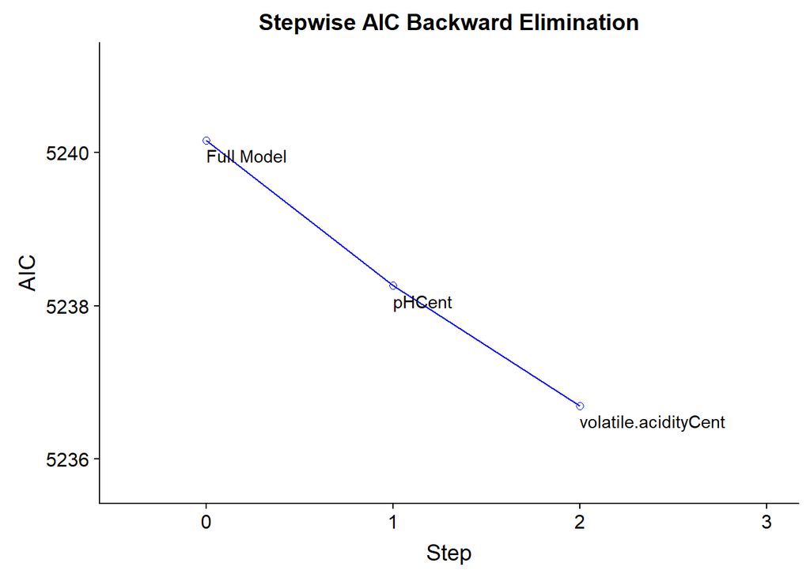

```r
# view stepwise AIC backward elimination
plot(backward)
```

The backward selection removes pHCent and volatile.acidityCent from the model.

```r
# forward selection process
forward <- ols_step_forward_aic(full.model, details=TRUE)
```

```
## Forward Selection Method
## ------------------------
##
## Candidate Terms:
##
## 1 . volatile.acidityCent
## 2 . residual.sugarCent
## 3 . citric.acid
## 4 . chloridesCent
## 5 . free.sulfur.dioxideCent
## 6 . sulphatesCent
## 7 . densityCent
## 8 . pHCent
## 9 . alcoholCent
##
##  Step 0: AIC = 5315.392
##  quality ~ 1
##
## -------------------------------------------------------------------------------------
## Variable                   DF      AIC       Sum Sq      RSS       R-Sq     Adj. R-Sq
## -------------------------------------------------------------------------------------
## alcoholCent                 1    5258.957    93.085    2500.905    0.036        0.035
## citric.acid                 1    5292.863    39.488    2554.502    0.015        0.015
## volatile.acidityCent        1    5302.658    23.791    2570.199    0.009        0.009
## sulphatesCent               1    5305.527    19.176    2574.814    0.007        0.007
## free.sulfur.dioxideCent     1    5309.439    12.869    2581.121    0.005        0.004
## densityCent                 1    5311.101    10.185    2583.805    0.004        0.003
## residual.sugarCent          1    5312.626     7.720    2586.270    0.003        0.002
## chloridesCent               1    5315.451     3.146    2590.844    0.001        0.001
## pHCent                      1    5315.916     2.392    2591.598    0.001        0.000
## -------------------------------------------------------------------------------------
##
##
## - alcoholCent
##
##
##  Step 1 : AIC = 5258.957
##  quality ~ alcoholCent
##
## -------------------------------------------------------------------------------------
```

[output cut: 141 more lines]

```
## ----------------------------------------------------------------------
##
##                                         Parameter Estimates
## ----------------------------------------------------------------------------------------------------
##                   model      Beta    Std. Error    Std. Beta      t        Sig      lower     upper
## ----------------------------------------------------------------------------------------------------
##             (Intercept)     4.196         0.060                 69.649    0.000     4.078     4.314
##             alcoholCent    -1.480         0.426       -0.115    -3.474    0.001    -2.316    -0.645
##             citric.acid    -0.713         0.191       -0.109    -3.743    0.000    -1.087    -0.340
## free.sulfur.dioxideCent     0.122         0.047        0.066     2.617    0.009     0.031     0.214
##           sulphatesCent    -0.549         0.211       -0.073    -2.601    0.009    -0.963    -0.135
##      residual.sugarCent    -0.064         0.025       -0.070    -2.534    0.011    -0.113    -0.014
##             densityCent    50.620        24.227        0.075     2.089    0.037     3.101    98.139
##           chloridesCent     1.282         0.751        0.047     1.707    0.088    -0.191     2.755
## ----------------------------------------------------------------------------------------------------
```

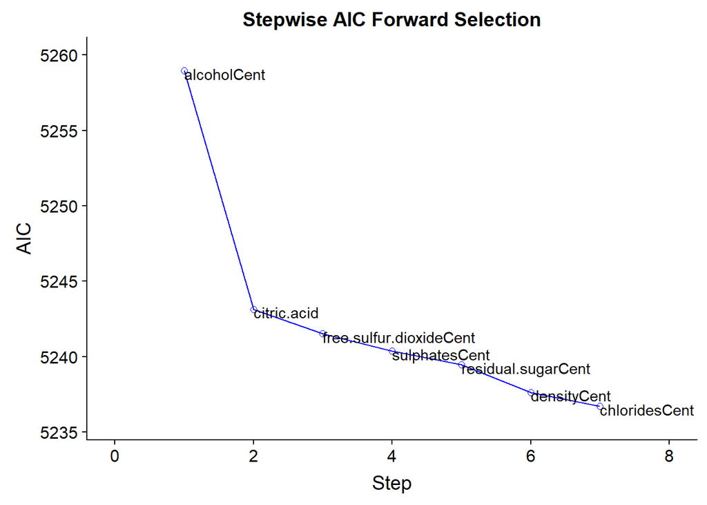

```r
# view stepwise AIC forward selection
plot(forward)
```

We can see the foward selection process includes the same explanatory variables as the model from the backward selection - both models do not include volatile.acidityCent and pHCent from the full.model.

```r
# stepwise selection process
stepwise <- ols_step_both_aic(full.model, details=TRUE)
```

```
## Stepwise Selection Method
## -------------------------
##
## Candidate Terms:
##
## 1 . volatile.acidityCent
## 2 . residual.sugarCent
## 3 . citric.acid
## 4 . chloridesCent
## 5 . free.sulfur.dioxideCent
## 6 . sulphatesCent
## 7 . densityCent
## 8 . pHCent
## 9 . alcoholCent
##
##  Step 0: AIC = 5315.392
##  quality ~ 1
##
##
##                                   Enter New Variables
## -------------------------------------------------------------------------------------
## Variable                   DF      AIC       Sum Sq      RSS       R-Sq     Adj. R-Sq
## -------------------------------------------------------------------------------------
## alcoholCent                 1    5258.957    93.085    2500.905    0.036        0.035
## citric.acid                 1    5292.863    39.488    2554.502    0.015        0.015
## volatile.acidityCent        1    5302.658    23.791    2570.199    0.009        0.009
## sulphatesCent               1    5305.527    19.176    2574.814    0.007        0.007
## free.sulfur.dioxideCent     1    5309.439    12.869    2581.121    0.005        0.004
## densityCent                 1    5311.101    10.185    2583.805    0.004        0.003
## residual.sugarCent          1    5312.626     7.720    2586.270    0.003        0.002
## chloridesCent               1    5315.451     3.146    2590.844    0.001        0.001
## pHCent                      1    5315.916     2.392    2591.598    0.001        0.000
## -------------------------------------------------------------------------------------
##
## - alcoholCent added
##
##
##  Step 1 : AIC = 5258.957
##  quality ~ alcoholCent
##
```

[output cut: 201 more lines]

```
## ----------------------------------------------------------------------
##
##                                         Parameter Estimates
## ----------------------------------------------------------------------------------------------------
##                   model      Beta    Std. Error    Std. Beta      t        Sig      lower     upper
## ----------------------------------------------------------------------------------------------------
##             (Intercept)     4.196         0.060                 69.649    0.000     4.078     4.314
##             alcoholCent    -1.480         0.426       -0.115    -3.474    0.001    -2.316    -0.645
##             citric.acid    -0.713         0.191       -0.109    -3.743    0.000    -1.087    -0.340
## free.sulfur.dioxideCent     0.122         0.047        0.066     2.617    0.009     0.031     0.214
##           sulphatesCent    -0.549         0.211       -0.073    -2.601    0.009    -0.963    -0.135
##      residual.sugarCent    -0.064         0.025       -0.070    -2.534    0.011    -0.113    -0.014
##             densityCent    50.620        24.227        0.075     2.089    0.037     3.101    98.139
##           chloridesCent     1.282         0.751        0.047     1.707    0.088    -0.191     2.755
## ----------------------------------------------------------------------------------------------------
```

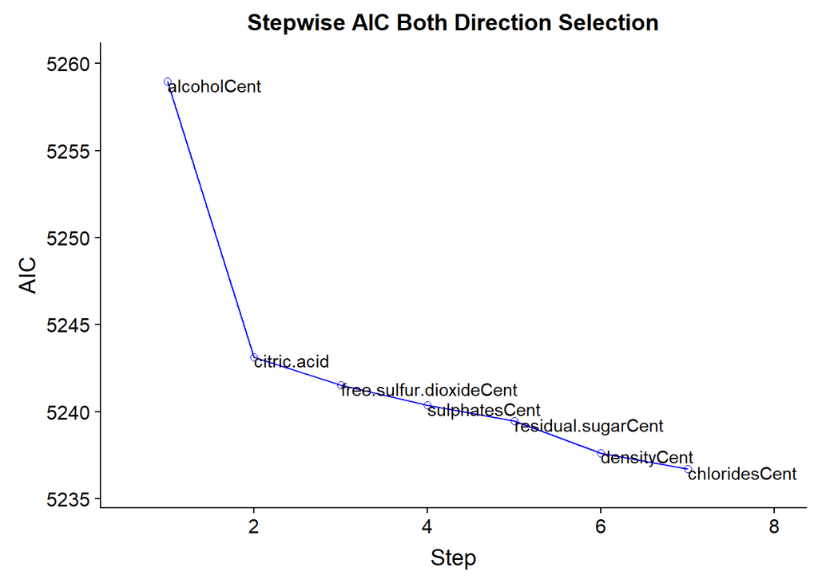

```r
# view stepwise AIC two-direction selection
plot(stepwise)
```

The plot for stepwise selection looks the same as the plot for forward selection. Therefore, for all three model selections, we obtain the same result of including all variables from the full.model, except for volatile.acidityCent and pHCent.

```r
# new model from model selection
selected <- lm(quality ~ residual.sugarCent + citric.acid + chloridesCent + free.sulfur.dioxideCent + sulphatesCent + densityCent + alcoholCent, data=data)
```

```r
# view coefficients of the new model
kable(tidy(selected), format="markdown")
```

| term | estimate | std.error | statistic | p.value |
| --- | --- | --- | --- | --- |
| (Intercept) | 4.1958029 | 0.0602418 | 69.649417 | 0.0000000 |
| residual.sugarCent | -0.0635406 | 0.0250780 | -2.533722 | 0.0113811 |
| citric.acid | -0.7133533 | 0.1905764 | -3.743135 | 0.0001882 |
| chloridesCent | 1.2819261 | 0.7508357 | 1.707332 | 0.0879554 |
| free.sulfur.dioxideCent | 0.1222369 | 0.0467139 | 2.616716 | 0.0089621 |
| sulphatesCent | -0.5491415 | 0.2111665 | -2.600514 | 0.0093946 |
| densityCent | 50.6199746 | 24.2265654 | 2.089441 | 0.0368266 |
| alcoholCent | -1.4804306 | 0.4261511 | -3.473957 | 0.0005266 |

```r
# model after removing chloridesCent
model <- lm(quality ~ residual.sugarCent + citric.acid + free.sulfur.dioxideCent + sulphatesCent + densityCent + alcoholCent, data=data)
```

```r
# view the model
kable(tidy(model), format="markdown")
```

| term | estimate | std.error | statistic | p.value |
| --- | --- | --- | --- | --- |
| (Intercept) | 4.1836612 | 0.0598565 | 69.894862 | 0.0000000 |
| residual.sugarCent | -0.0596820 | 0.0249909 | -2.388146 | 0.0170496 |
| citric.acid | -0.6685459 | 0.1888743 | -3.539635 | 0.0004122 |
| free.sulfur.dioxideCent | 0.1174678 | 0.0466583 | 2.517618 | 0.0119126 |
| sulphatesCent | -0.4152295 | 0.1961778 | -2.116598 | 0.0344488 |
| densityCent | 47.1628067 | 24.1563106 | 1.952401 | 0.0510657 |
| alcoholCent | -1.6866114 | 0.4089281 | -4.124470 | 0.0000391 |

```r
# multicollinearity check
kable(tidy(vif(model)))
```

| names | x |
| --- | --- |
| residual.sugarCent | 1.287930 |
| citric.acid | 1.404305 |
| free.sulfur.dioxideCent | 1.060577 |
| sulphatesCent | 1.147117 |
| densityCent | 2.156214 |
| alcoholCent | 1.696738 |

A quick examination of the model using the VIF() function shows no noticeable detection of multicollinearity effects - all vif values are quite small, ranging around 1 to 2.

We will then examine possible interaction effects between the selected variables.

## Nested F Tests on Interactions

```r
# interaction effects with residual.sugarCent
model_rs <- lm(quality ~ residual.sugarCent + citric.acid + free.sulfur.dioxideCent + sulphatesCent + densityCent + alcoholCent + residual.sugarCent*citric.acid + residual.sugarCent*free.sulfur.dioxideCent + residual.sugarCent*sulphatesCent + residual.sugarCent*densityCent + residual.sugarCent*alcoholCent, data=data)
```

```r
# Nested F Test for interaction with residual.sugarCent
ano1 <- anova(model_rs, model)
kable(tidy(ano1))
```

| res.df | rss | df | sumsq | statistic | p.value |
| --- | --- | --- | --- | --- | --- |
| 1587 | 2444.878 | NA | NA | NA | NA |
| 1592 | 2452.374 | -5 | -7.496334 | 0.9731922 | 0.4328145 |

p-value is much higher than 0.05, so there is no significant interactions with residual.sugarCent that impact wine quality.

```r
# Nested F Test for interaction effect between alcohol and density
model_da <- lm(quality ~ residual.sugarCent + citric.acid + free.sulfur.dioxideCent + sulphatesCent + densityCent + alcoholCent + alcoholCent*densityCent, data=data)
ano2 <- anova(model_da, model)
kable(tidy(ano2))
```

| res.df | rss | df | sumsq | statistic | p.value |
| --- | --- | --- | --- | --- | --- |
| 1591 | 2451.562 | NA | NA | NA | NA |
| 1592 | 2452.374 | -1 | -0.8127848 | 0.5274763 | 0.4677767 |

p-value is much larger than 0.05, so there is no significant interaction effect between alcoholCent an densityCent.

```r
# Nested F Test for all other two-way interactions
model1 <- lm(quality ~ residual.sugarCent + citric.acid + free.sulfur.dioxideCent + sulphatesCent + densityCent + alcoholCent + citric.acid*free.sulfur.dioxideCent + citric.acid*sulphatesCent + citric.acid*densityCent + citric.acid*alcoholCent + free.sulfur.dioxideCent*sulphatesCent + free.sulfur.dioxideCent*densityCent + free.sulfur.dioxideCent*alcoholCent + sulphatesCent*densityCent + sulphatesCent*alcoholCent, data=data)
ano3 <- anova(model1, model)
kable(tidy(ano3))
```

| res.df | rss | df | sumsq | statistic | p.value |
| --- | --- | --- | --- | --- | --- |
| 1583 | 2345.719 | NA | NA | NA | NA |
| 1592 | 2452.374 | -9 | -106.6554 | 7.997331 | 0 |

The p-value is extremely small, so there is at least one significant interaction effects. We will then investigate which specific interactions are significant using backward model selection.

```r
# backward selection
backward_new <- ols_step_backward_aic(model1, details=TRUE)
```

```
## Backward Elimination Method
## ---------------------------
##
## Candidate Terms:
##
## 1 . residual.sugarCent
## 2 . citric.acid
## 3 . free.sulfur.dioxideCent
## 4 . sulphatesCent
## 5 . densityCent
## 6 . alcoholCent
## 7 . citric.acid:free.sulfur.dioxideCent
## 8 . citric.acid:sulphatesCent
## 9 . citric.acid:densityCent
## 10 . citric.acid:alcoholCent
## 11 . free.sulfur.dioxideCent:sulphatesCent
## 12 . free.sulfur.dioxideCent:densityCent
## 13 . free.sulfur.dioxideCent:alcoholCent
## 14 . sulphatesCent:densityCent
## 15 . sulphatesCent:alcoholCent
##
##  Step 0: AIC = 5184.524
##  quality ~ residual.sugarCent + citric.acid + free.sulfur.dioxideCent + sulphatesCent + densityCent + alcoholCent + citric.acid:free.sulfur.dioxideCent + citric.acid:sulphatesCent + citric.acid:densityCent + citric.acid:alcoholCent + free.sulfur.dioxideCent:sulphatesCent + free.sulfur.dioxideCent…
##
## ---------------------------------------------------------------------------------------------------
## Variable                                 DF      AIC       Sum Sq      RSS       R-Sq     Adj. R-Sq
## ---------------------------------------------------------------------------------------------------
## free.sulfur.dioxideCent:sulphatesCent    1     5182.524     0.000    2345.719    0.096        0.088
## citric.acid:densityCent                  1     5182.532     0.012    2345.731    0.096        0.088
## sulphatesCent                            1     5182.630     0.155    2345.874    0.096        0.088
## sulphatesCent:densityCent                1     5182.801     0.407    2346.126    0.096        0.088
## free.sulfur.dioxideCent:densityCent      1     5182.870     0.507    2346.226    0.096        0.088
## citric.acid:alcoholCent                  1     5183.014     0.719    2346.438    0.095        0.087
## densityCent                              1     5184.248     2.531    2348.250    0.095        0.087
## alcoholCent                              1     5184.831     3.387    2349.106    0.094        0.086
## residual.sugarCent                       1     5186.560     5.929    2351.648    0.093        0.085
## citric.acid:free.sulfur.dioxideCent      1     5187.894     7.891    2353.610    0.093        0.085
## citric.acid:sulphatesCent                1     5188.496     8.778    2354.497    0.092        0.084
## free.sulfur.dioxideCent:alcoholCent      1     5190.557    11.815    2357.534    0.091        0.083
## citric.acid                              1     5193.316    15.885    2361.604    0.090        0.082
```

[output cut: 177 more lines]

```
##                                                 Parameter Estimates
## -------------------------------------------------------------------------------------------------------------------
##                               model       Beta    Std. Error    Std. Beta      t        Sig       lower      upper
## -------------------------------------------------------------------------------------------------------------------
##                         (Intercept)      4.223         0.058                 72.659    0.000      4.109      4.337
##                  residual.sugarCent     -0.051         0.025       -0.056    -2.047    0.041     -0.099     -0.002
##                         citric.acid     -0.625         0.186       -0.096    -3.359    0.001     -0.990     -0.260
##             free.sulfur.dioxideCent      0.318         0.079        0.171     4.014    0.000      0.163      0.473
##                         densityCent     57.046        23.735        0.085     2.403    0.016     10.492    103.600
##                         alcoholCent     -1.507         0.405       -0.117    -3.724    0.000     -2.300     -0.713
## citric.acid:free.sulfur.dioxideCent     -0.663         0.233       -0.124    -2.844    0.005     -1.119     -0.206
##           citric.acid:sulphatesCent     -2.468         0.491       -0.136    -5.025    0.000     -3.432     -1.505
## free.sulfur.dioxideCent:alcoholCent      1.859         0.464        0.099     4.009    0.000      0.949      2.768
##           alcoholCent:sulphatesCent    -14.841         2.069       -0.187    -7.172    0.000    -18.900    -10.782
## -------------------------------------------------------------------------------------------------------------------
```

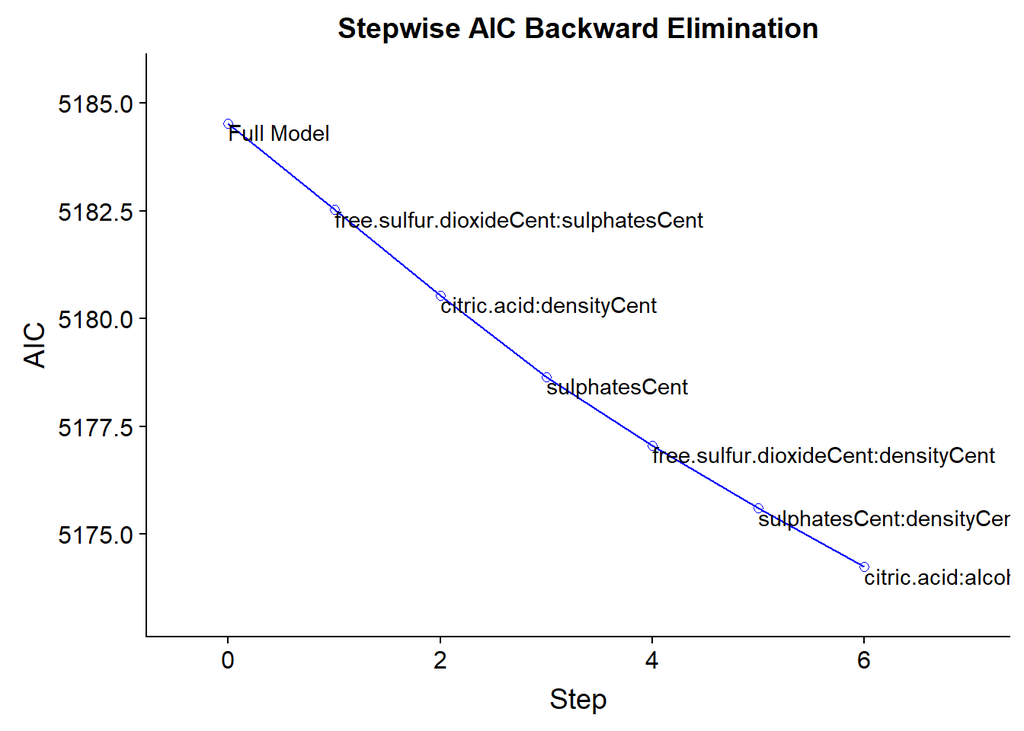

```r
# view the stepwise AIC backward elimination
plot(backward_new)
```

Backward model selection removes 5 interaction effects and sulphatesCent. However, since the model still includes some interaction effects with sulphatesCent, we will keep this main effect in the model.

```r
# new model after backward selection
model2 <- lm(quality ~ residual.sugarCent + citric.acid + free.sulfur.dioxideCent + sulphatesCent + densityCent + alcoholCent + citric.acid*free.sulfur.dioxideCent + citric.acid*sulphatesCent + free.sulfur.dioxideCent*alcoholCent + sulphatesCent*alcoholCent, data=data)
kable(tidy(model2), format="markdown")
```

| term | estimate | std.error | statistic | p.value |
| --- | --- | --- | --- | --- |
| (Intercept) | 4.2171683 | 0.0590778 | 71.3833241 | 0.0000000 |
| residual.sugarCent | -0.0518568 | 0.0248550 | -2.0863774 | 0.0371037 |
| citric.acid | -0.6173180 | 0.1866933 | -3.3065894 | 0.0009655 |
| free.sulfur.dioxideCent | 0.3241281 | 0.0799055 | 4.0563949 | 0.0000523 |
| sulphatesCent | -0.2121836 | 0.3554581 | -0.5969299 | 0.5506393 |
| densityCent | 59.0975138 | 23.9869181 | 2.4637393 | 0.0138549 |
| alcoholCent | -1.4643592 | 0.4107550 | -3.5650429 | 0.0003746 |
| citric.acid:free.sulfur.dioxideCent | -0.6757339 | 0.2340284 | -2.8874016 | 0.0039370 |
| citric.acid:sulphatesCent | -2.0553378 | 0.8485023 | -2.4223127 | 0.0155334 |
| free.sulfur.dioxideCent:alcoholCent | 1.8859989 | 0.4659745 | 4.0474296 | 0.0000543 |
| sulphatesCent:alcoholCent | -14.9448598 | 2.0771193 | -7.1949936 | 0.0000000 |

We can see that p-value of all the coefficients are less than the threshold of 0.05, except for sulphatesCent. Therefore, these main and interaction effects are significant predictors of wine quality (besides sulphatesCent). So we will make model2 our final model.

```r
# make model2 the final multiple regression model
final.model <- lm(quality ~ residual.sugarCent + citric.acid + free.sulfur.dioxideCent + sulphatesCent + densityCent + alcoholCent + citric.acid*free.sulfur.dioxideCent + citric.acid*sulphatesCent + free.sulfur.dioxideCent*alcoholCent + sulphatesCent*alcoholCent, data=data)
```

## Assumptions

### Residual Plots

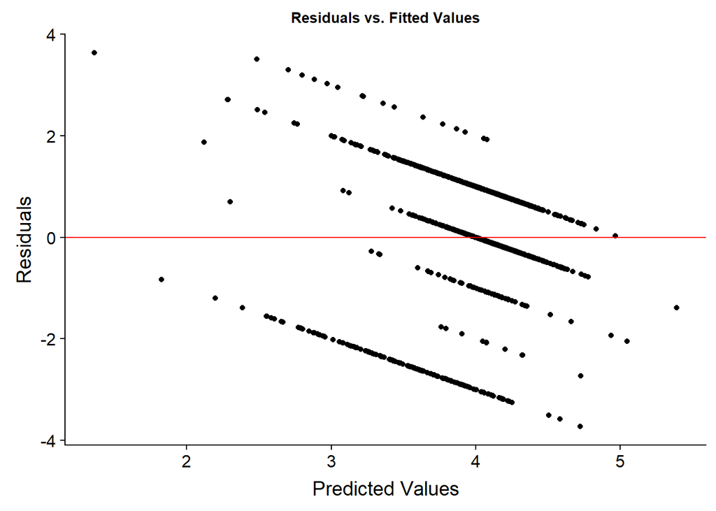

```r
data <- data %>% mutate(predicted = predict.lm(final.model))
data <- data %>% mutate(resid=resid(final.model))
ggplot(data, aes(predicted, resid)) + geom_point() +
  geom_hline(yintercept=0, color="red") + labs(x="Predicted Values", y="Residuals",
  title="Residuals vs. Fitted Values") + theme(plot.title=element_text(hjust=0.5,
  size=10))
```

### Normaltiy

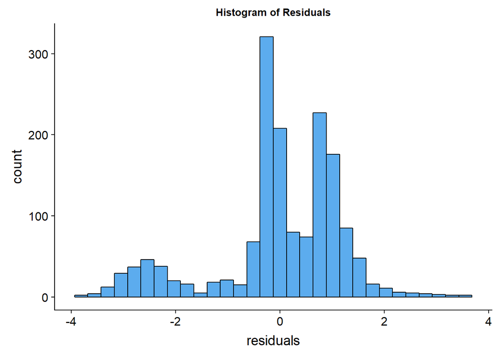

```r
# distribution of residuals
ggplot(data, aes(resid)) + geom_histogram(color="black",
  fill="steelblue2") + labs(x="residuals", y="count", title="Histogram of Residuals") +
  theme(plot.title=element_text(hjust=0.5, size=10))
```

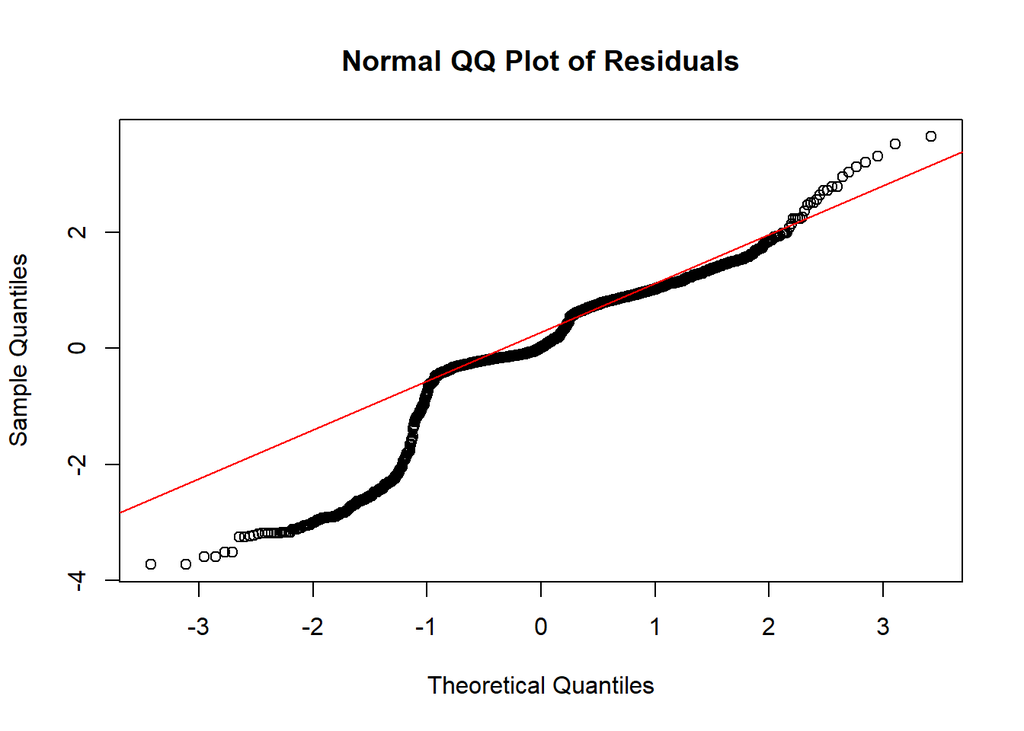

```r
# QQ Plot
qqnorm(data$resid, main="Normal QQ Plot of Residuals")
qqline(data$resid, col="red")
```

### Influence Points

```r
data <- data %>% mutate(leverage = hatvalues(final.model), cooks =
  cooks.distance(final.model), stand.resid = rstandard(final.model), obs.num =
  row_number())
```

```r
# calculate leverage threshold
t <- 2*10/1599
```

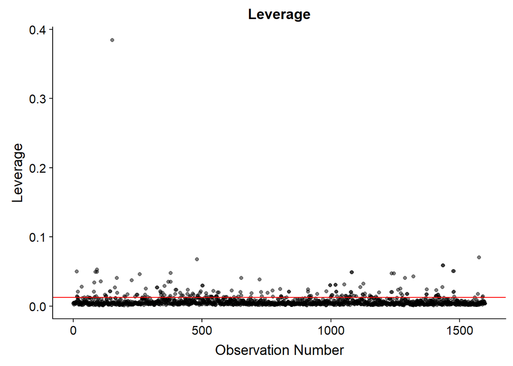

```r
# leverage
ggplot(data=data, aes(x=obs.num, y=leverage)) +
  geom_point(alpha=0.5) +
  geom_hline(yintercept=t, color="red") +
  labs(x="Observation Number", y="Leverage", title="Leverage")
```

We can see that there is one point with a significantly high leverage around 0.4, comparing with other observations. This could be an outlier and might be an influence point.

```r
#data %>% filter(leverage > 0.3) %>%
  #select(citric.acid, residual.sugarCent, free.sulfur.dioxideCent, sulphatesCent, densityCent, alcoholCent)
```

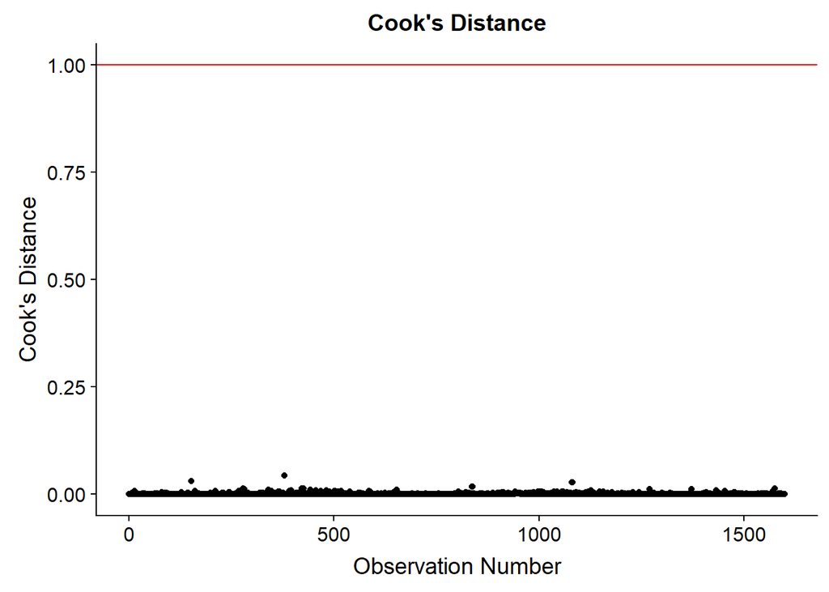

```r
# Cookâs Distance
ggplot(data=data, aes(x=obs.num, y=cooks)) +
  geom_point() +
  geom_hline(yintercept=1, color="red")+
  labs(x="Observation Number", y="Cook's Distance", title="Cook's Distance")
```

The Cookâs Distance for all observations are far below the threshold of 1.

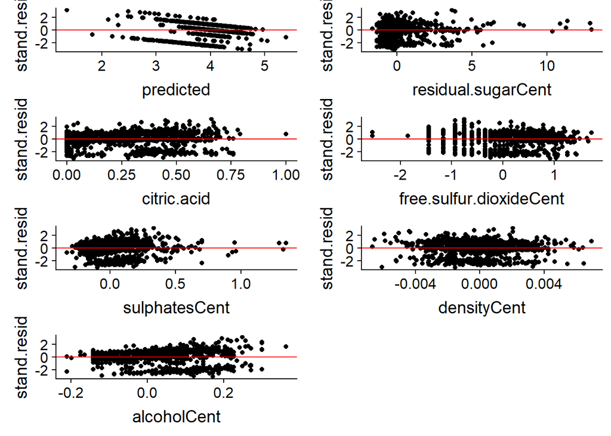

```r
# standardized residuals
p1 <- ggplot(data=data, aes(x=predicted, y=stand.resid)) + geom_point()+  geom_hline(yintercept=0, color="red")
p2 <- ggplot(data=data, aes(x=residual.sugarCent, y=stand.resid)) + geom_point()+  geom_hline(yintercept=0, color="red")
p3 <- ggplot(data=data, aes(x=citric.acid, y=stand.resid)) + geom_point()+  geom_hline(yintercept=0, color="red")
p4 <- ggplot(data=data, aes(x=free.sulfur.dioxideCent, y=stand.resid)) + geom_point()+  geom_hline(yintercept=0, color="red")
p5 <- ggplot(data=data, aes(x=sulphatesCent, y=stand.resid)) + geom_point()+  geom_hline(yintercept=0, color="red")
p6 <- ggplot(data=data, aes(x=densityCent, y=stand.resid)) + geom_point()+  geom_hline(yintercept=0, color="red")
p7 <- ggplot(data=data, aes(x=alcoholCent, y=stand.resid)) + geom_point()+  geom_hline(yintercept=0, color="red")

plot_grid(p1, p2, p3, p4, p5, p6, p7, ncol=2, nrow=4)
```

The standardized residuals show some points with magnitude greater than 2, but overall, in combination with our observation from Cookâs Distance and just one data point with high leverage away from other points, we can conclude there isn’t any obvious influential points in this model.

### Multicollinearity

```r
kable(tidy(vif(final.model)))
```

| names | x |
| --- | --- |
| residual.sugarCent | 1.327405 |
| citric.acid | 1.429631 |
| free.sulfur.dioxideCent | 3.241062 |
| sulphatesCent | 3.924059 |
| densityCent | 2.215287 |
| alcoholCent | 1.783762 |
| citric.acid:free.sulfur.dioxideCent | 3.366221 |
| citric.acid:sulphatesCent | 3.844940 |
| free.sulfur.dioxideCent:alcoholCent | 1.088148 |
| sulphatesCent:alcoholCent | 1.197212 |

## Additional Work

```r
# compare model from stepwise selection with final model from backward selection
stepwise_new <- ols_step_both_aic(model1, details=TRUE)
```

```
## Stepwise Selection Method
## -------------------------
##
## Candidate Terms:
##
## 1 . residual.sugarCent
## 2 . citric.acid
## 3 . free.sulfur.dioxideCent
## 4 . sulphatesCent
## 5 . densityCent
## 6 . alcoholCent
## 7 . citric.acid:free.sulfur.dioxideCent
## 8 . citric.acid:sulphatesCent
## 9 . citric.acid:densityCent
## 10 . citric.acid:alcoholCent
## 11 . free.sulfur.dioxideCent:sulphatesCent
## 12 . free.sulfur.dioxideCent:densityCent
## 13 . free.sulfur.dioxideCent:alcoholCent
## 14 . sulphatesCent:densityCent
## 15 . sulphatesCent:alcoholCent
##
##  Step 0: AIC = 5315.392
##  quality ~ 1
##
##
##                                          Enter New Variables
## ----------------------------------------------------------------------------------------------------
## Variable                                 DF      AIC       Sum Sq       RSS       R-Sq     Adj. R-Sq
## ----------------------------------------------------------------------------------------------------
## citric.acid:alcoholCent                   1    5251.440    104.815    2489.175    0.040        0.040
## alcoholCent                               1    5258.957     93.085    2500.905    0.036        0.035
## sulphatesCent:alcoholCent                 1    5292.404     40.222    2553.768    0.016        0.015
## citric.acid                               1    5292.863     39.488    2554.502    0.015        0.015
## citric.acid:sulphatesCent                 1    5303.179     22.954    2571.036    0.009        0.008
## free.sulfur.dioxideCent:alcoholCent       1    5303.975     21.674    2572.316    0.008        0.008
## sulphatesCent                             1    5305.527     19.176    2574.814    0.007        0.007
## free.sulfur.dioxideCent                   1    5309.439     12.869    2581.121    0.005        0.004
## densityCent                               1    5311.101     10.185    2583.805    0.004        0.003
## free.sulfur.dioxideCent:densityCent       1    5311.630      9.331    2584.659    0.004        0.003
## residual.sugarCent                        1    5312.626      7.720    2586.270    0.003        0.002
```

[output cut: 357 more lines]

```
##                                                 Parameter Estimates
## -------------------------------------------------------------------------------------------------------------------
##                               model       Beta    Std. Error    Std. Beta      t        Sig       lower      upper
## -------------------------------------------------------------------------------------------------------------------
##                         (Intercept)      4.193         0.055                 76.797    0.000      4.086      4.301
##                         alcoholCent     -1.794         0.343       -0.139    -5.225    0.000     -2.468     -1.121
##             free.sulfur.dioxideCent      0.310         0.079        0.167     3.913    0.000      0.155      0.466
##                         citric.acid     -0.577         0.179       -0.088    -3.218    0.001     -0.929     -0.225
##                  residual.sugarCent     -0.042         0.023       -0.046    -1.779    0.075     -0.088      0.004
##           citric.acid:sulphatesCent     -2.481         0.492       -0.137    -5.041    0.000     -3.446     -1.515
##           sulphatesCent:alcoholCent    -14.570         2.061       -0.183    -7.070    0.000    -18.612    -10.527
## alcoholCent:free.sulfur.dioxideCent      1.803         0.464        0.096     3.882    0.000      0.892      2.714
## citric.acid:free.sulfur.dioxideCent     -0.649         0.234       -0.121    -2.776    0.006     -1.107     -0.190
##             citric.acid:densityCent    122.401        52.579        0.068     2.328    0.020     19.269    225.534
## -------------------------------------------------------------------------------------------------------------------
```

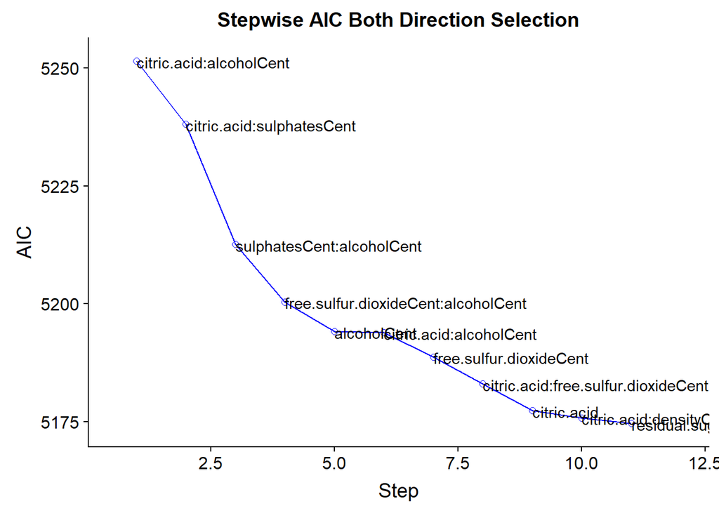

```r
# view the stepwise AIC backward elimination
plot(stepwise_new)
```

# Bob Logistic Regression

```r
rawdata <- read.csv("./redwine_quality.csv")
data$quality <- rawdata$quality
data$quality[data$quality < 6] <- 0
data$quality[data$quality >= 6] <- 1

# Model Reduced
modellg1.null <- glm(quality ~ 1, data=data , family=binomial)

# Model Full
modellg1.full <- glm(quality ~ volatile.acidityCent  + residual.sugarCent + citric.acid + chloridesCent + free.sulfur.dioxideCent + sulphatesCent + densityCent + pHCent + alcoholCent,data=data, family = binomial)
```

```r
# forward Selection
step(modellg1.null,scope=list(upper=modellg1.full),direction="forward")
```

```
## Start:  AIC=2210.97
## quality ~ 1
##
##                           Df Deviance    AIC
## + alcoholCent              1   1864.6 1868.6
## + volatile.acidityCent     1   2033.4 2037.4
## + sulphatesCent            1   2122.8 2126.8
## + densityCent              1   2167.8 2171.8
## + citric.acid              1   2168.0 2172.0
## + chloridesCent            1   2188.6 2192.6
## + free.sulfur.dioxideCent  1   2203.7 2207.7
## <none>                         2209.0 2211.0
## + pHCent                   1   2209.0 2213.0
## + residual.sugarCent       1   2209.0 2213.0
##
## Step:  AIC=1868.56
## quality ~ alcoholCent
##
##                           Df Deviance    AIC
## + volatile.acidityCent     1   1751.5 1757.5
## + sulphatesCent            1   1804.2 1810.2
## + citric.acid              1   1840.5 1846.5
## + pHCent                   1   1846.1 1852.1
## + densityCent              1   1857.9 1863.9
## <none>                         1864.6 1868.6
## + residual.sugarCent       1   1863.8 1869.8
## + free.sulfur.dioxideCent  1   1863.9 1869.9
## + chloridesCent            1   1864.4 1870.4
##
## Step:  AIC=1757.46
## quality ~ alcoholCent + volatile.acidityCent
##
##                           Df Deviance    AIC
## + sulphatesCent            1   1723.5 1731.5
## + densityCent              1   1749.3 1757.3
## <none>                         1751.5 1757.5
## + pHCent                   1   1749.6 1757.6
## + citric.acid              1   1749.8 1757.8
## + free.sulfur.dioxideCent  1   1750.7 1758.7
## + residual.sugarCent       1   1750.8 1758.8
```

[output cut: 40 more lines]

```
##
##                           Df Deviance    AIC
## + densityCent              1   1702.9 1718.9
## <none>                         1705.5 1719.5
## + free.sulfur.dioxideCent  1   1703.8 1719.8
## + residual.sugarCent       1   1705.4 1721.4
##
## Step:  AIC=1718.9
## quality ~ alcoholCent + volatile.acidityCent + sulphatesCent +
##     chloridesCent + citric.acid + pHCent + densityCent
##
##                           Df Deviance    AIC
## <none>                         1702.9 1718.9
## + free.sulfur.dioxideCent  1   1701.3 1719.3
## + residual.sugarCent       1   1701.6 1719.6
```

```
##
## Call:  glm(formula = quality ~ alcoholCent + volatile.acidityCent +
##     sulphatesCent + chloridesCent + citric.acid + pHCent + densityCent,
##     family = binomial, data = data)
##
## Coefficients:
##          (Intercept)           alcoholCent  volatile.acidityCent
##               0.6812               11.2044               -3.7391
##        sulphatesCent         chloridesCent           citric.acid
##               2.5311               -3.7075               -1.6186
##               pHCent           densityCent
##              -1.0366               72.6658
##
## Degrees of Freedom: 1598 Total (i.e. Null);  1591 Residual
## Null Deviance:       2209
## Residual Deviance: 1703  AIC: 1719
```

```r
modellg1.selected <- glm(quality ~ alcoholCent  + volatile.acidityCent + sulphatesCent + chloridesCent + free.sulfur.dioxideCent + citric.acid + pHCent + densityCent,data=data, family = binomial)
summary(modellg1.selected)
```

```
##
## Call:
## glm(formula = quality ~ alcoholCent + volatile.acidityCent +
##     sulphatesCent + chloridesCent + free.sulfur.dioxideCent +
##     citric.acid + pHCent + densityCent, family = binomial, data = data)
##
## Deviance Residuals:
##     Min       1Q   Median       3Q      Max
## -3.1740  -0.8612   0.3316   0.8467   2.4447
##
## Coefficients:
##                         Estimate Std. Error z value Pr(>|z|)
## (Intercept)              0.68555    0.14714   4.659 3.17e-06 ***
## alcoholCent             11.09221    0.88379  12.551  < 2e-16 ***
## volatile.acidityCent    -3.75741    0.47977  -7.832 4.81e-15 ***
## sulphatesCent            2.58005    0.45398   5.683 1.32e-08 ***
## chloridesCent           -3.74071    1.52037  -2.460  0.01388 *
## free.sulfur.dioxideCent -0.11363    0.08942  -1.271  0.20385
## citric.acid             -1.63471    0.50733  -3.222  0.00127 **
## pHCent                  -0.97306    0.48801  -1.994  0.04616 *
## densityCent             70.68938   44.93433   1.573  0.11568
## ---
## Signif. codes:  0 '***' 0.001 '**' 0.01 '*' 0.05 '.' 0.1 ' ' 1
##
## (Dispersion parameter for binomial family taken to be 1)
##
##     Null deviance: 2209.0  on 1598  degrees of freedom
## Residual deviance: 1701.3  on 1590  degrees of freedom
## AIC: 1719.3
##
## Number of Fisher Scoring iterations: 4
```

```r
kable(tidy(modellg1.selected))
```

| term | estimate | std.error | statistic | p.value |
| --- | --- | --- | --- | --- |
| (Intercept) | 0.6855452 | 0.1471388 | 4.659175 | 0.0000032 |
| alcoholCent | 11.0922130 | 0.8837906 | 12.550725 | 0.0000000 |
| volatile.acidityCent | -3.7574115 | 0.4797663 | -7.831753 | 0.0000000 |
| sulphatesCent | 2.5800500 | 0.4539767 | 5.683222 | 0.0000000 |
| chloridesCent | -3.7407077 | 1.5203663 | -2.460399 | 0.0138783 |
| free.sulfur.dioxideCent | -0.1136251 | 0.0894214 | -1.270669 | 0.2038463 |
| citric.acid | -1.6347115 | 0.5073271 | -3.222204 | 0.0012721 |
| pHCent | -0.9730581 | 0.4880139 | -1.993915 | 0.0461614 |
| densityCent | 70.6893766 | 44.9343338 | 1.573171 | 0.1156793 |

```r
modellg1.final <- glm(quality ~ alcoholCent  + volatile.acidityCent + sulphatesCent + chloridesCent + free.sulfur.dioxideCent + citric.acid,data=data, family = binomial)
summary(modellg1.final)
```

```
##
## Call:
## glm(formula = quality ~ alcoholCent + volatile.acidityCent +
##     sulphatesCent + chloridesCent + free.sulfur.dioxideCent +
##     citric.acid, family = binomial, data = data)
##
## Deviance Residuals:
##     Min       1Q   Median       3Q      Max
## -3.0128  -0.8718   0.3366   0.8696   2.3936
##
## Coefficients:
##                         Estimate Std. Error z value Pr(>|z|)
## (Intercept)              0.47616    0.12057   3.949 7.84e-05 ***
## alcoholCent             10.02378    0.73841  13.575  < 2e-16 ***
## volatile.acidityCent    -3.51862    0.44963  -7.826 5.06e-15 ***
## sulphatesCent            2.67223    0.44586   5.993 2.05e-09 ***
## chloridesCent           -3.68484    1.47139  -2.504   0.0123 *
## free.sulfur.dioxideCent -0.13818    0.08894  -1.554   0.1203
## citric.acid             -0.84637    0.39195  -2.159   0.0308 *
## ---
## Signif. codes:  0 '***' 0.001 '**' 0.01 '*' 0.05 '.' 0.1 ' ' 1
##
## (Dispersion parameter for binomial family taken to be 1)
##
##     Null deviance: 2209.0  on 1598  degrees of freedom
## Residual deviance: 1707.9  on 1592  degrees of freedom
## AIC: 1721.9
##
## Number of Fisher Scoring iterations: 4
```

```r
kable(tidy(modellg1.final))
```

| term | estimate | std.error | statistic | p.value |
| --- | --- | --- | --- | --- |
| (Intercept) | 0.4761648 | 0.1205680 | 3.949346 | 0.0000784 |
| alcoholCent | 10.0237751 | 0.7384068 | 13.574868 | 0.0000000 |
| volatile.acidityCent | -3.5186155 | 0.4496337 | -7.825516 | 0.0000000 |
| sulphatesCent | 2.6722324 | 0.4458566 | 5.993479 | 0.0000000 |
| chloridesCent | -3.6848433 | 1.4713913 | -2.504326 | 0.0122685 |
| free.sulfur.dioxideCent | -0.1381811 | 0.0889366 | -1.553703 | 0.1202552 |
| citric.acid | -0.8463692 | 0.3919501 | -2.159380 | 0.0308207 |

```r
kable(tidy(vif(modellg1.final)))
```

| names | x |
| --- | --- |
| alcoholCent | 1.054815 |
| volatile.acidityCent | 1.535221 |
| sulphatesCent | 1.413263 |
| chloridesCent | 1.432024 |
| free.sulfur.dioxideCent | 1.021080 |
| citric.acid | 1.651468 |

```r
data$pred <- predict.glm(modellg1.final)
data$res <- residuals.glm(modellg1.final)
```

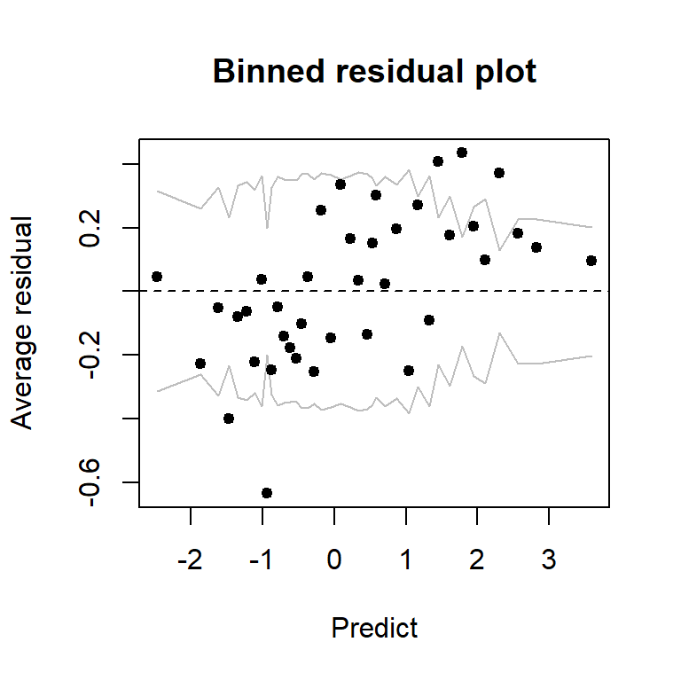

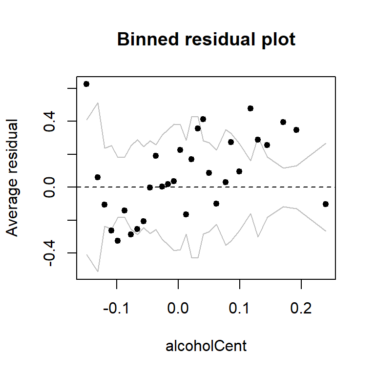

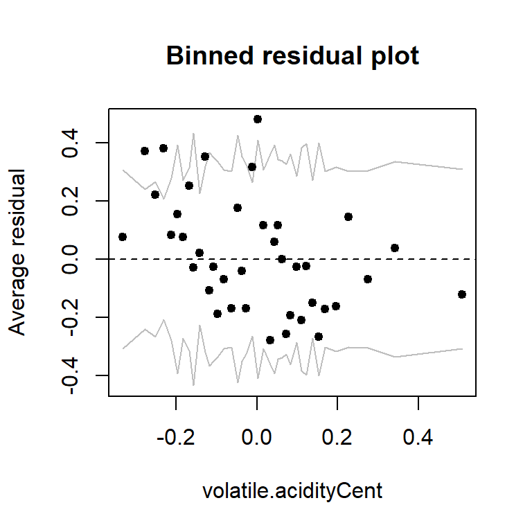

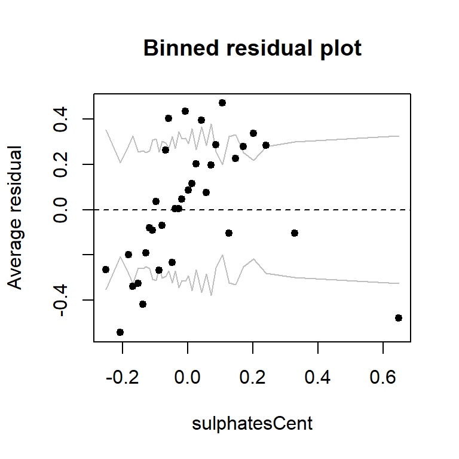

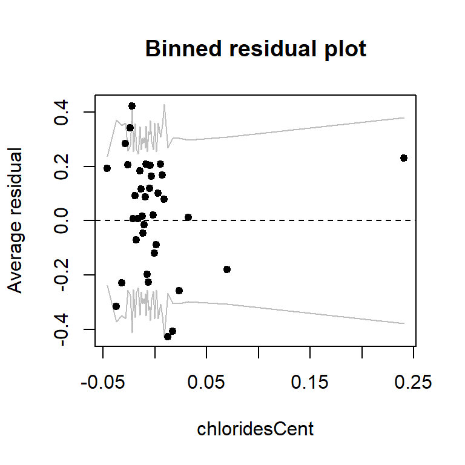

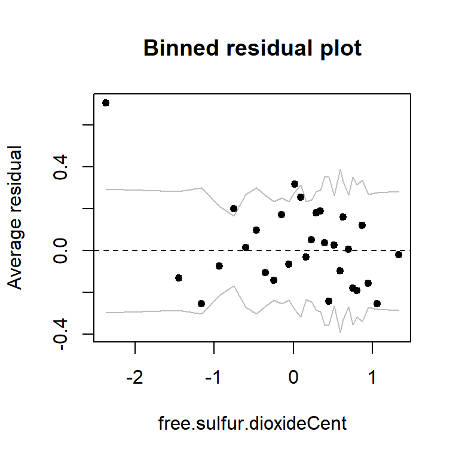

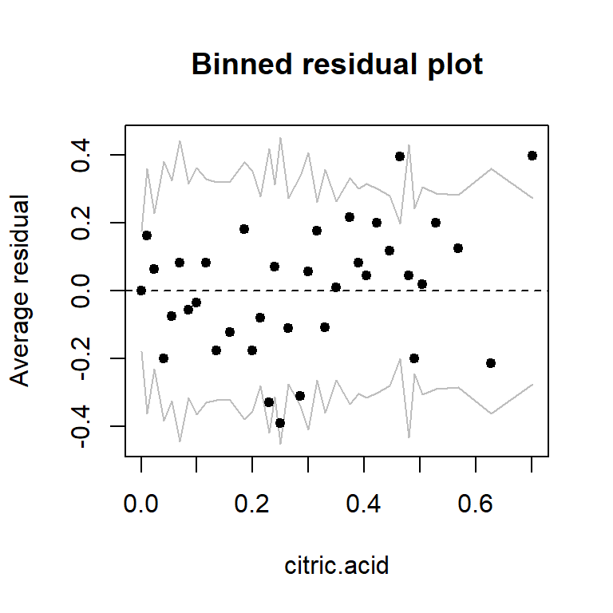

sulfates cent need transformation volatile.acidityCent also needs tranformation alcoholCent also needs transformation

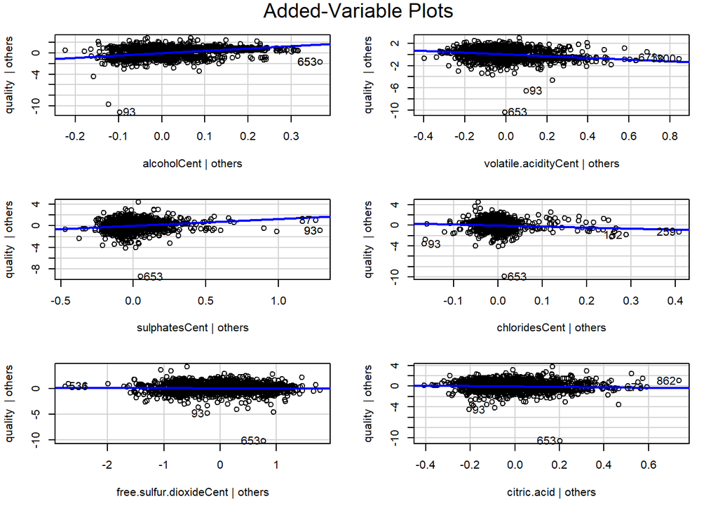

```r
avPlots(modellg1.final)
```

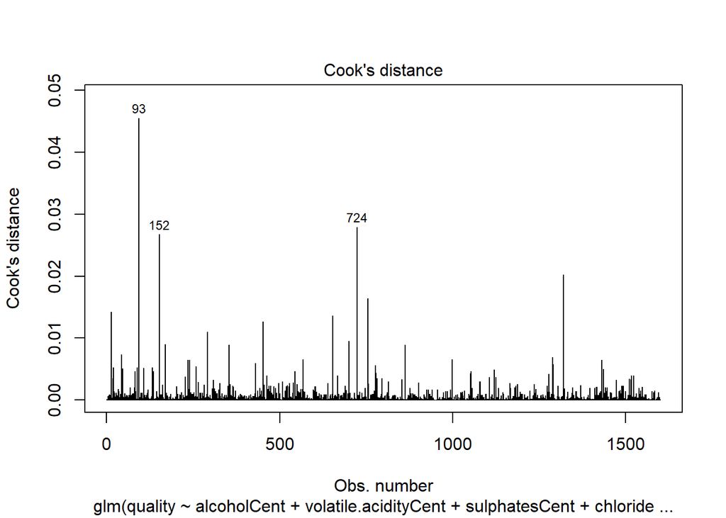

```r
cutoff <- cooks.distance(modellg1.final)
plot(modellg1.final, which=4, cook.levels=cutoff)
```

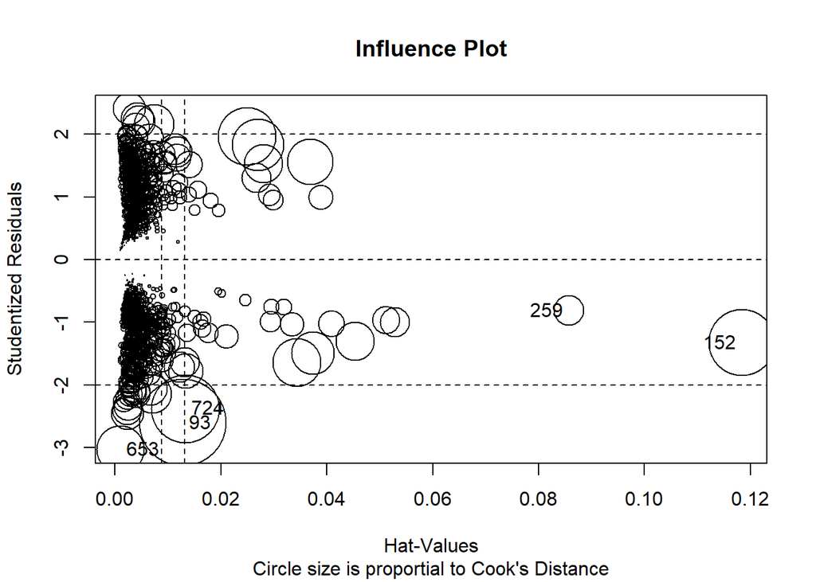

```
##        StudRes         Hat       CookD
## 93  -2.6030374 0.012781717 0.045518612
## 152 -1.3291883 0.118400902 0.026716482
## 259 -0.8150245 0.085705218 0.005418863
## 653 -3.0285632 0.001027607 0.013614397
## 724 -2.3778456 0.013267141 0.027920054
```

```r
influencePlot(modellg1.final,    main="Influence Plot", sub="Circle size is proportial to Cook's Distance" )
```

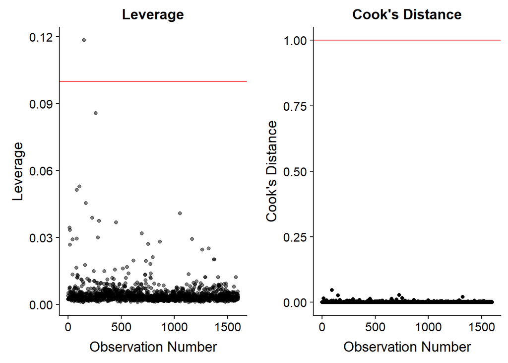

```r
data <- data %>%
  mutate(leverage = hatvalues(modellg1.final),
         cooks = cooks.distance(modellg1.final),
         stand.resid = rstandard(modellg1.final),
         obs.num = row_number())
p3 <- ggplot(data=data, aes(x=obs.num,y=leverage)) +
  geom_point(alpha=0.5) +
  geom_hline(yintercept=0.1,color="red")+
  labs(x="Observation Number",y="Leverage",title="Leverage")

p4 <- ggplot(data=data, aes(x=obs.num,y=cooks)) +
  geom_point() +
  geom_hline(yintercept=1,color="red")+
  labs(x="Observation Number",y="Cook's Distance",title="Cook's Distance")

plot_grid(p3,p4,ncol = 2)
```

no significant outlier or influential plot.

## Lynn-Interactions on Logistic Regression

```r
# interaction effects with change in deviance test
modellg1.final <- glm(quality ~ alcoholCent  + volatile.acidityCent + sulphatesCent + chloridesCent + free.sulfur.dioxideCent + citric.acid,data=data, family = binomial)
modellg2 <- glm(quality ~ alcoholCent  + volatile.acidityCent + sulphatesCent + chloridesCent + free.sulfur.dioxideCent + citric.acid + alcoholCent*volatile.acidityCent, data=data, family = binomial)
modellg3 <- glm(quality ~ alcoholCent  + volatile.acidityCent + sulphatesCent + chloridesCent + free.sulfur.dioxideCent + citric.acid + alcoholCent*sulphatesCent, data=data, family = binomial)
modellg4 <- glm(quality ~ alcoholCent  + volatile.acidityCent + sulphatesCent + chloridesCent + free.sulfur.dioxideCent + citric.acid + volatile.acidityCent*sulphatesCent, data=data, family = binomial)
tidy(anova(modellg1.final,modellg2,test="Chisq"))
```

```
## # A tibble: 2 x 5
##   Resid..Df Resid..Dev    df Deviance p.value
## *     <dbl>      <dbl> <dbl>    <dbl>   <dbl>
## 1      1592      1708.    NA   NA      NA
## 2      1591      1708.     1    0.340   0.560
```

```r
tidy(anova(modellg1.final,modellg3,test="Chisq"))
```

```
## # A tibble: 2 x 5
##   Resid..Df Resid..Dev    df Deviance  p.value
## *     <dbl>      <dbl> <dbl>    <dbl>    <dbl>
## 1      1592      1708.    NA    NA    NA
## 2      1591      1700.     1     8.11  0.00441
```

```r
tidy(anova(modellg1.final,modellg4,test="Chisq"))
```

```
## # A tibble: 2 x 5
##   Resid..Df Resid..Dev    df Deviance p.value
## *     <dbl>      <dbl> <dbl>    <dbl>   <dbl>
## 1      1592      1708.    NA   NA      NA
## 2      1591      1708.     1    0.156   0.693
```

Based on the three test, we discover significant interaction between alcoholCent and sulphatesCent, and we are including it in our model.

```r
#final logistic regression model
final.model.lg <- glm(quality ~ alcoholCent  + volatile.acidityCent + sulphatesCent + chloridesCent + free.sulfur.dioxideCent + citric.acid + alcoholCent*sulphatesCent, data=data, family = binomial)
summary(final.model.lg)
```

```
##
## Call:
## glm(formula = quality ~ alcoholCent + volatile.acidityCent +
##     sulphatesCent + chloridesCent + free.sulfur.dioxideCent +
##     citric.acid + alcoholCent * sulphatesCent, family = binomial,
##     data = data)
##
## Deviance Residuals:
##     Min       1Q   Median       3Q      Max
## -3.4014  -0.8641   0.2756   0.8714   2.3399
##
## Coefficients:
##                           Estimate Std. Error z value Pr(>|z|)
## (Intercept)                0.51790    0.12232   4.234 2.30e-05 ***
## alcoholCent               10.44043    0.76474  13.652  < 2e-16 ***
## volatile.acidityCent      -3.48741    0.45285  -7.701 1.35e-14 ***
## sulphatesCent              3.28206    0.50259   6.530 6.57e-11 ***
## chloridesCent             -2.19566    1.57507  -1.394  0.16332
## free.sulfur.dioxideCent   -0.15447    0.08918  -1.732  0.08323 .
## citric.acid               -0.94679    0.39627  -2.389  0.01688 *
## alcoholCent:sulphatesCent 15.43251    5.50456   2.804  0.00505 **
## ---
## Signif. codes:  0 '***' 0.001 '**' 0.01 '*' 0.05 '.' 0.1 ' ' 1
##
## (Dispersion parameter for binomial family taken to be 1)
##
##     Null deviance: 2209.0  on 1598  degrees of freedom
## Residual deviance: 1699.8  on 1591  degrees of freedom
## AIC: 1715.8
##
## Number of Fisher Scoring iterations: 5
```

## Lynn-Ordinal Logistic Regression

Because of the natural ordering of the Y variable, quality, we believe ordinal logistic regression might be a good model to explain the variation of quality. ### Exploratory analysis

```r
#reload the data because quality was taken as binary in logistic
data <- data %>% mutate(quality_dup=quality)
data$quality_dup <- rawdata$quality
## create separate indicator variables for each level of quality to use in binned plots
data <- data %>% mutate(qua0 = if_else(quality_dup=="0",1,0),
                            qua1 = if_else(quality_dup=="1",1,0),
                            qua2 = if_else(quality_dup=="2",1,0),
                            qua3 = if_else(quality_dup=="3",1,0),
                            qua4 = if_else(quality_dup=="4",1,0),
                            qua5 = if_else(quality_dup=="5",1,0),
                            qua6 = if_else(quality_dup=="6",1,0),
                            qua7 = if_else(quality_dup=="7",1,0),
                            qua8 = if_else(quality_dup=="8",1,0),
                            qua9 = if_else(quality_dup=="9",1,0),
                            qua10 = if_else(quality_dup=="10",1,0))
```

### Model

```r
data <- data %>% mutate(quality_dup=as.factor(quality_dup))
m1 <- polr(quality_dup ~ volatile.acidityCent + residual.sugarCent + citric.acid + chloridesCent + free.sulfur.dioxideCent + sulphatesCent + densityCent + pHCent + alcoholCent, data=data)
summary(m1)
```

```
##
## Re-fitting to get Hessian
```

```
## Call:
## polr(formula = quality_dup ~ volatile.acidityCent + residual.sugarCent +
##     citric.acid + chloridesCent + free.sulfur.dioxideCent + sulphatesCent +
##     densityCent + pHCent + alcoholCent, data = data)
##
## Coefficients:
##                            Value Std. Error t value
## volatile.acidityCent    -3.75104    0.39326 -9.5383
## residual.sugarCent       0.01691    0.04171  0.4055
## citric.acid             -0.99815    0.42359 -2.3564
## chloridesCent           -5.00530    1.32694 -3.7721
## free.sulfur.dioxideCent -0.07996    0.07614 -1.0501
## sulphatesCent            2.68128    0.37083  7.2306
## densityCent             39.85808   40.66914  0.9801
## pHCent                  -1.42886    0.41695 -3.4269
## alcoholCent             10.59221    0.76761 13.7990
##
## Intercepts:
##     Value    Std. Error t value
## 3|4  -6.1763   0.3497   -17.6611
## 4|5  -4.2358   0.1899   -22.3046
## 5|6  -0.5609   0.1267    -4.4276
## 6|7   2.2503   0.1461    15.3976
## 7|8   5.2385   0.2751    19.0458
##
## Residual Deviance: 3105.809
## AIC: 3133.809
```

```r
kable(tidy(m1),format="markdown",digits=3)
```

| term | estimate | std.error | statistic | coefficient_type |
| --- | --- | --- | --- | --- |
| volatile.acidityCent | -3.751 | 0.393 | -9.538 | coefficient |
| residual.sugarCent | 0.017 | 0.042 | 0.406 | coefficient |
| citric.acid | -0.998 | 0.424 | -2.356 | coefficient |
| chloridesCent | -5.005 | 1.327 | -3.772 | coefficient |
| free.sulfur.dioxideCent | -0.080 | 0.076 | -1.050 | coefficient |
| sulphatesCent | 2.681 | 0.371 | 7.231 | coefficient |
| densityCent | 39.858 | 40.669 | 0.980 | coefficient |
| pHCent | -1.429 | 0.417 | -3.427 | coefficient |
| alcoholCent | 10.592 | 0.768 | 13.799 | coefficient |
| 3\|4 | -6.176 | 0.350 | -17.661 | zeta |
| 4\|5 | -4.236 | 0.190 | -22.305 | zeta |
| 5\|6 | -0.561 | 0.127 | -4.428 | zeta |
| 6\|7 | 2.250 | 0.146 | 15.398 | zeta |
| 7\|8 | 5.239 | 0.275 | 19.046 | zeta |

```r
#parameter estimates with confidence level
confint.default(m1)
```

```
##
## Re-fitting to get Hessian
```

```
##                                2.5 %       97.5 %
## volatile.acidityCent     -4.52181117  -2.98026563
## residual.sugarCent       -0.06484235   0.09867230
## citric.acid              -1.82837211  -0.16793611
## chloridesCent            -7.60604259  -2.40454924
## free.sulfur.dioxideCent  -0.22919515   0.06928352
## sulphatesCent             1.95447693   3.40809024
## densityCent             -39.85196999 119.56813377
## pHCent                   -2.24606891  -0.61164232
## alcoholCent               9.08772825  12.09669422
```

If the 95% CI does not cross 0, the parameter estimate is statistically significant. The CI for volatile.acidityCent, citric.acid, chloridesCent, sulphatesCent, pHCent and alcoholCent do not include 0, so we take them as significant and remove residual.sugarCent, free.sulfur.dioxideCent and densityCent from the model.

```r
m2 <- polr(quality_dup ~ volatile.acidityCent + citric.acid + chloridesCent + sulphatesCent + pHCent + alcoholCent, data=data)
summary(m2)
```

```
##
## Re-fitting to get Hessian
```

```
## Call:
## polr(formula = quality_dup ~ volatile.acidityCent + citric.acid +
##     chloridesCent + sulphatesCent + pHCent + alcoholCent, data = data)
##
## Coefficients:
##                        Value Std. Error t value
## volatile.acidityCent -3.6196     0.3782  -9.571
## citric.acid          -0.7449     0.3754  -1.985
## chloridesCent        -5.1183     1.3110  -3.904
## sulphatesCent         2.7138     0.3620   7.498
## pHCent               -1.4741     0.4148  -3.554
## alcoholCent          10.2434     0.6230  16.441
##
## Intercepts:
##     Value    Std. Error t value
## 3|4  -6.1049   0.3443   -17.7320
## 4|5  -4.1572   0.1788   -23.2447
## 5|6  -0.4920   0.1160    -4.2405
## 6|7   2.3198   0.1364    17.0024
## 7|8   5.3099   0.2690    19.7362
##
## Residual Deviance: 3108.772
## AIC: 3130.772
```

```r
confint.default(m2)
```

```
##
## Re-fitting to get Hessian
```

```
##                          2.5 %       97.5 %
## volatile.acidityCent -4.360762 -2.878355406
## citric.acid          -1.480615 -0.009212258
## chloridesCent        -7.687797 -2.548858417
## sulphatesCent         2.004370  3.423211424
## pHCent               -2.287143 -0.661069088
## alcoholCent           9.022288 11.464558115
```

```r
#get odds ratios
exp(coef(m2))
```

```
## volatile.acidityCent          citric.acid        chloridesCent
##         2.679450e-02         4.747753e-01         5.986024e-03
##        sulphatesCent               pHCent          alcoholCent
##         1.508636e+01         2.289833e-01         2.809714e+04
```

```r
## OR and CI
ci <- confint(m2)
```

```
##
## Re-fitting to get Hessian
```

```r
exp(cbind(OR = coef(m2), ci))
```

```
##                                OR        2.5 %       97.5 %
## volatile.acidityCent 2.679450e-02 1.275579e-02 5.617706e-02
## citric.acid          4.747753e-01 2.274263e-01 9.908378e-01
## chloridesCent        5.986024e-03 4.487540e-04 7.658795e-02
## sulphatesCent        1.508636e+01 7.467187e+00 3.088016e+01
## pHCent               2.289833e-01 1.013057e-01 5.152596e-01
## alcoholCent          2.809714e+04 8.338917e+03 9.594383e+04
```

### Prediction

```r
# calculate predicted probabilities for each observation
predprobs <- data.frame(predict(m2,type="probs"))
predprobs %>% filter(row_number() <= 3) #print predictions for first three observations
```

```
##            X3         X4        X5        X6         X7           X8
## 1 0.018455348 0.09803944 0.7209189 0.1510529 0.01094703 0.0005863696
## 2 0.011901141 0.06598463 0.6895225 0.2147030 0.01697368 0.0009150662
## 3 0.009152362 0.05168262 0.6559021 0.2600629 0.02200706 0.0011928715
```

```r
# predicted categories
data <- data %>% mutate(pred.comp = predict(m2,type="class")) # get predicted categories
result <- data %>% group_by(pred.comp,quality_dup) %>% summarise(n=n()) # summarise actual vs. predicted
kable(spread(result,quality_dup,n),format="markdown") # print actual vs. predicted categories
```

| pred.comp | 3 | 4 | 5 | 6 | 7 | 8 |
| --- | --- | --- | --- | --- | --- | --- |
| 4 | 1 | NA | NA | NA | NA | NA |
| 5 | 8 | 39 | 507 | 218 | 9 | NA |
| 6 | 1 | 14 | 170 | 390 | 139 | 10 |
| 7 | NA | NA | 4 | 30 | 51 | 8 |

### Model Diagnostics

```r
data <- data %>% mutate(resid3 = qua3-predprobs[,1],
                            resid4 = qua4-predprobs[,2],
                            resid5 = qua5-predprobs[,3],
                            resid6 = qua6-predprobs[,4],
                            resid7 = qua7-predprobs[,5],
                            resid8 = qua8-predprobs[,6])
data$predor <- predict(m2, data)
```

```r
data %>% count(predor,quality_dup)
```

```
## # A tibble: 16 x 3
##    predor quality_dup     n
##    <fct>  <fct>       <int>
##  1 4      3               1
##  2 5      3               8
##  3 5      4              39
##  4 5      5             507
##  5 5      6             218
##  6 5      7               9
##  7 6      3               1
##  8 6      4              14
##  9 6      5             170
## 10 6      6             390
## 11 6      7             139
## 12 6      8              10
## 13 7      5               4
## 14 7      6              30
## 15 7      7              51
## 16 7      8               8
```

```r
confusionMatrix(data$predor,data$quality_dup)
```

```
## Confusion Matrix and Statistics
##
##           Reference
## Prediction   3   4   5   6   7   8
##          3   0   0   0   0   0   0
##          4   1   0   0   0   0   0
##          5   8  39 507 218   9   0
##          6   1  14 170 390 139  10
##          7   0   0   4  30  51   8
##          8   0   0   0   0   0   0
##
## Overall Statistics
##
##                Accuracy : 0.5929
##                  95% CI : (0.5683, 0.6171)
##     No Information Rate : 0.4259
##     P-Value [Acc > NIR] : < 2.2e-16
##
##                   Kappa : 0.326
##  Mcnemar's Test P-Value : NA
##
## Statistics by Class:
##
##                      Class: 3  Class: 4 Class: 5 Class: 6 Class: 7
## Sensitivity          0.000000 0.0000000   0.7445   0.6113  0.25628
## Specificity          1.000000 0.9993532   0.7015   0.6524  0.97000
## Pos Pred Value            NaN 0.0000000   0.6492   0.5387  0.54839
## Neg Pred Value       0.993746 0.9668335   0.7873   0.7166  0.90173
## Prevalence           0.006254 0.0331457   0.4259   0.3990  0.12445
## Detection Rate       0.000000 0.0000000   0.3171   0.2439  0.03189
## Detection Prevalence 0.000000 0.0006254   0.4884   0.4528  0.05816
## Balanced Accuracy    0.500000 0.4996766   0.7230   0.6319  0.61314
##                      Class: 8
## Sensitivity           0.00000
## Specificity           1.00000
## Pos Pred Value            NaN
## Neg Pred Value        0.98874
## Prevalence            0.01126
## Detection Rate        0.00000
## Detection Prevalence  0.00000
## Balanced Accuracy     0.50000
```

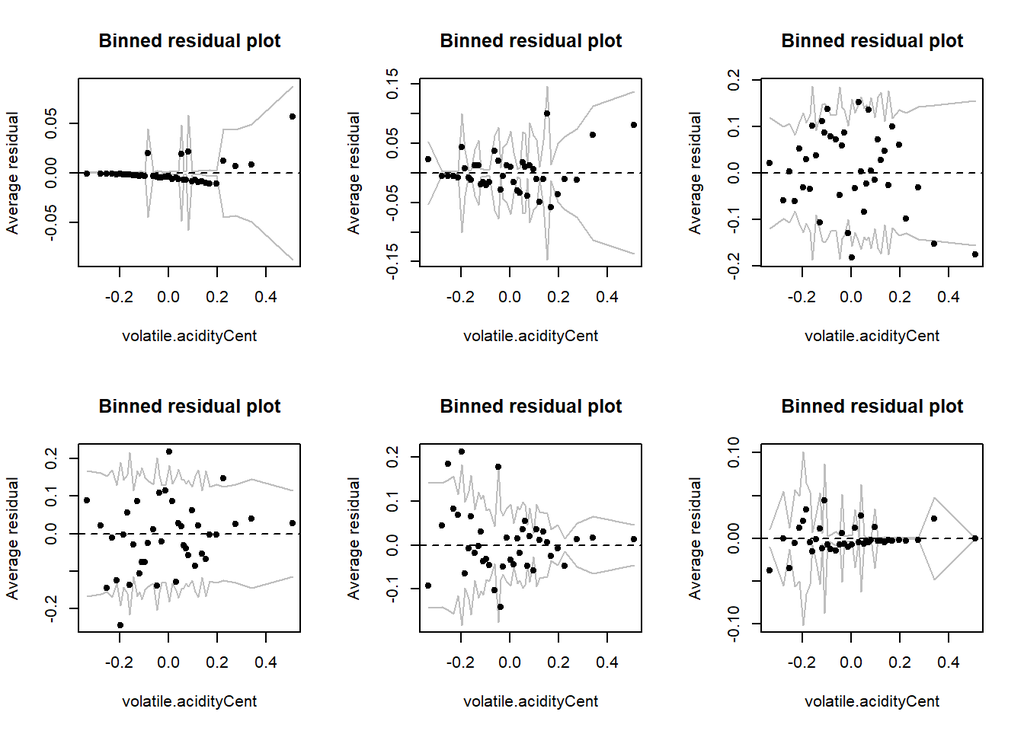

```r
# binned plots of residuals
par(mfrow=c(2,3))
arm::binnedplot(x=data$volatile.acidityCent,y=data$resid3,xlab="volatile.acidityCent")
arm::binnedplot(x=data$volatile.acidityCent,y=data$resid4,xlab="volatile.acidityCent")
arm::binnedplot(x=data$volatile.acidityCent,y=data$resid5,xlab="volatile.acidityCent")
arm::binnedplot(x=data$volatile.acidityCent,y=data$resid6,xlab="volatile.acidityCent")
arm::binnedplot(x=data$volatile.acidityCent,y=data$resid7,xlab="volatile.acidityCent")
arm::binnedplot(x=data$volatile.acidityCent,y=data$resid8,xlab="volatile.acidityCent")
```

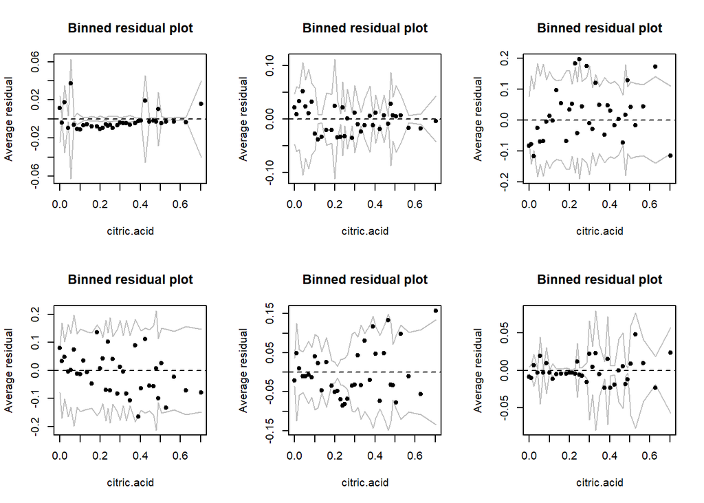

```r
par(mfrow=c(2,3))
arm::binnedplot(x=data$citric.acid,y=data$resid3,xlab="citric.acid")
arm::binnedplot(x=data$citric.acid,y=data$resid4,xlab="citric.acid")
arm::binnedplot(x=data$citric.acid,y=data$resid5,xlab="citric.acid")
arm::binnedplot(x=data$citric.acid,y=data$resid6,xlab="citric.acid")
arm::binnedplot(x=data$citric.acid,y=data$resid7,xlab="citric.acid")
arm::binnedplot(x=data$citric.acid,y=data$resid8,xlab="citric.acid")
```

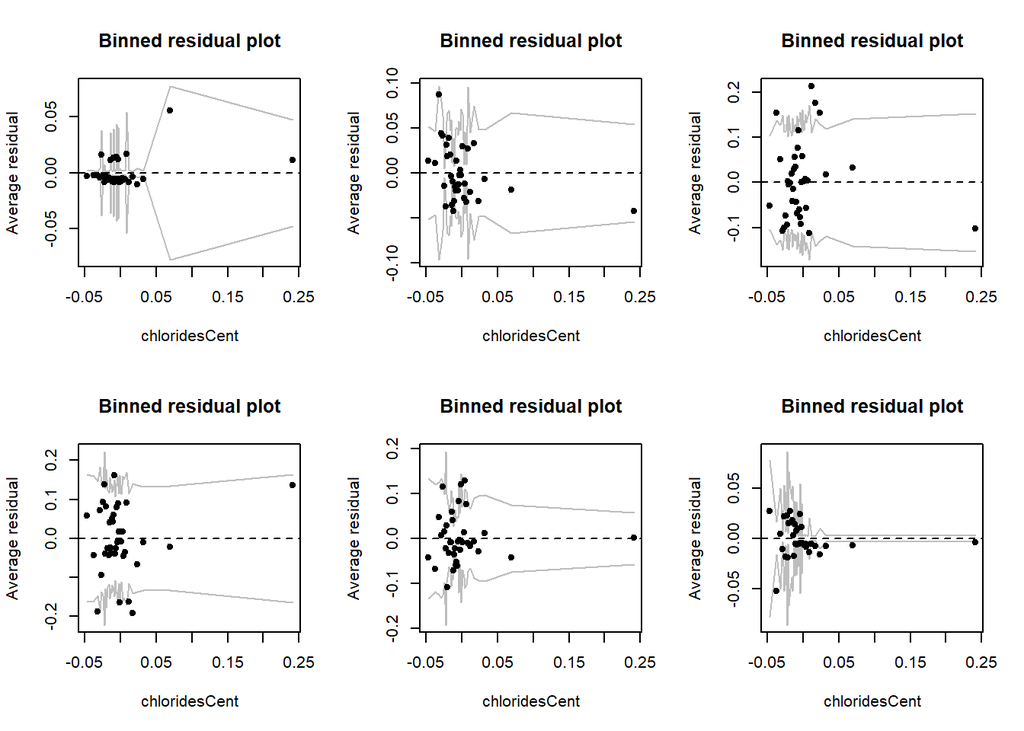

```r
par(mfrow=c(2,3))
arm::binnedplot(x=data$chloridesCent,y=data$resid3,xlab="chloridesCent")
arm::binnedplot(x=data$chloridesCent,y=data$resid4,xlab="chloridesCent")
arm::binnedplot(x=data$chloridesCent,y=data$resid5,xlab="chloridesCent")
arm::binnedplot(x=data$chloridesCent,y=data$resid6,xlab="chloridesCent")
arm::binnedplot(x=data$chloridesCent,y=data$resid7,xlab="chloridesCent")
arm::binnedplot(x=data$chloridesCent,y=data$resid8,xlab="chloridesCent")
```

*concerning residual patterns here*

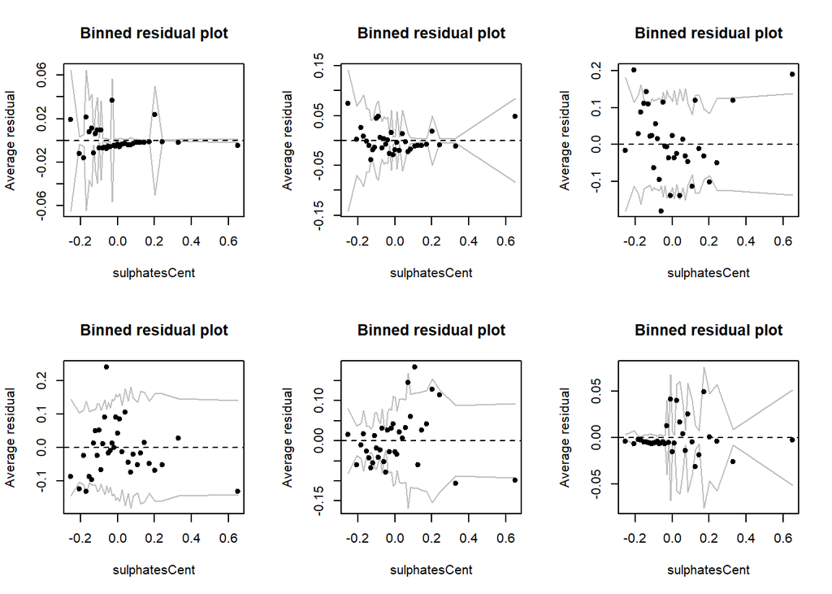

```r
par(mfrow=c(2,3))
arm::binnedplot(x=data$sulphatesCent,y=data$resid3,xlab="sulphatesCent")
arm::binnedplot(x=data$sulphatesCent,y=data$resid4,xlab="sulphatesCent")
arm::binnedplot(x=data$sulphatesCent,y=data$resid5,xlab="sulphatesCent")
arm::binnedplot(x=data$sulphatesCent,y=data$resid6,xlab="sulphatesCent")
arm::binnedplot(x=data$sulphatesCent,y=data$resid7,xlab="sulphatesCent")
arm::binnedplot(x=data$sulphatesCent,y=data$resid8,xlab="sulphatesCent")
```

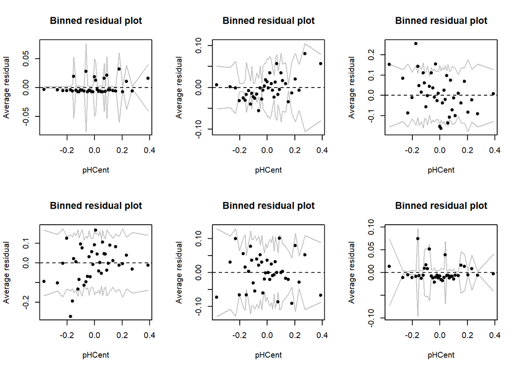

```r
par(mfrow=c(2,3))
arm::binnedplot(x=data$pHCent,y=data$resid3,xlab="pHCent")
arm::binnedplot(x=data$pHCent,y=data$resid4,xlab="pHCent")
arm::binnedplot(x=data$pHCent,y=data$resid5,xlab="pHCent")
arm::binnedplot(x=data$pHCent,y=data$resid6,xlab="pHCent")
arm::binnedplot(x=data$pHCent,y=data$resid7,xlab="pHCent")
arm::binnedplot(x=data$pHCent,y=data$resid8,xlab="pHCent")
```

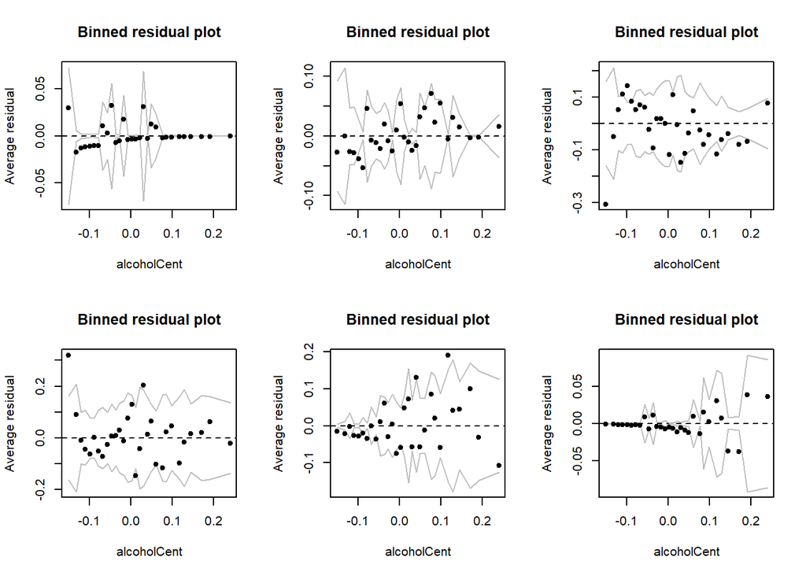

```r
par(mfrow=c(2,3))
arm::binnedplot(x=data$alcoholCent,y=data$resid3,xlab="alcoholCent")
arm::binnedplot(x=data$alcoholCent,y=data$resid4,xlab="alcoholCent")
arm::binnedplot(x=data$alcoholCent,y=data$resid5,xlab="alcoholCent")
arm::binnedplot(x=data$alcoholCent,y=data$resid6,xlab="alcoholCent")
arm::binnedplot(x=data$alcoholCent,y=data$resid7,xlab="alcoholCent")
arm::binnedplot(x=data$alcoholCent,y=data$resid8,xlab="alcoholCent")
```

```r
coeftest(m2)
```

```
##
## Re-fitting to get Hessian
```

```
##
## z test of coefficients:
##
##                      Estimate Std. Error  z value  Pr(>|z|)
## volatile.acidityCent -3.61956    0.37817  -9.5712 < 2.2e-16 ***
## citric.acid          -0.74491    0.37536  -1.9845   0.04720 *
## chloridesCent        -5.11833    1.31098  -3.9042 9.454e-05 ***
## sulphatesCent         2.71379    0.36196   7.4976 6.501e-14 ***
## pHCent               -1.47411    0.41482  -3.5536   0.00038 ***
## alcoholCent          10.24342    0.62304  16.4410 < 2.2e-16 ***
## 3|4                  -6.10487    0.34429 -17.7320 < 2.2e-16 ***
## 4|5                  -4.15715    0.17884 -23.2447 < 2.2e-16 ***
## 5|6                  -0.49199    0.11602  -4.2405 2.230e-05 ***
## 6|7                   2.31981    0.13644  17.0024 < 2.2e-16 ***
## 7|8                   5.30987    0.26904  19.7362 < 2.2e-16 ***
## ---
## Signif. codes:  0 '***' 0.001 '**' 0.01 '*' 0.05 '.' 0.1 ' ' 1
```